# Sintak analisis TPG UAS

Raziqizzan Putrandi

2023-12-05

# Pertemuan 8 Analisis Faktor

## Input data

Data yang digunakan merupakan data pelamar kerja, di mana seorang HRD ingin mengindentifikasi faktor-faktor yang dapat menjelaskan 12 peubah yang telah dikumpulkan oleh departemen mereka untuk mengukur setiap pelamar kerja. Pegawai HRD menilai pelamar kerja dengan menggunakan skala 1 (rendah) sampai 10 (tinggi). Mereka menggumpulkan penilaian untuk 50 pelamar kerja.

```r
library(psych)
```

```r
library(ggcorrplot)
data_jobApp <- read.csv("https://raw.githubusercontent.com/nurkhamidah/dat/main/job-applicants.csv", sep = ";")
head(data_jobApp)
```

```
##   Academic.record Appearance Communication Company.Fit Experience Job.Fit
## 1               6          8             7           5          6       5
## 2               9          8             8           8         10       9
## 3               6          7             7           6          6       7
## 4               7          8             6           5          8       5
## 5               4          7             8           6          6       6
## 6               7          7             7           5          5       6
##   Letter Likeability Organization Potential Resume Self.Confidence
## 1      7           7            7         6      7               7
## 2      8           9            8         9      9               9
## 3      7           8            8         6      6               8
## 4      9           8            7         8      7               7
## 5      6           7            8         5      4               6
## 6      5           7            8         7      4               6
```

## Tahap 1 - Eksplorasi Data dengan Melihat Korelasi Antar Peubah

Tujuan utama melihat korelasi data dalam analisis faktor adalah untuk memahami pola hubungan antara variabel-variabel dan memastikan bahwa data yang digunakan dalam analisis faktor sesuai dan relevan. Hal ini akan membantu dalam pemilihan variabel, penentuan jumlah faktor, dan interpretasi hasil analisis faktor.

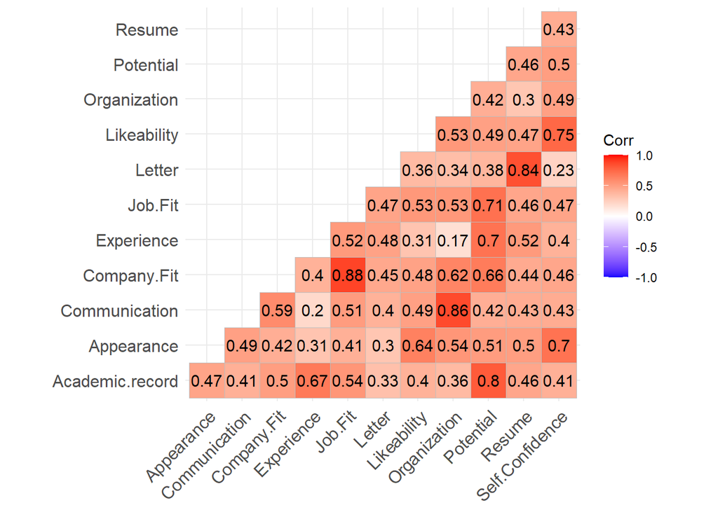

```r
cor_jobApp <- cor(data_jobApp)
ggcorrplot(cor_jobApp, type = "lower", lab = TRUE)
```

Jika diperhatikan hasil korelasi tersebut akan diperoleh beberapa kelompok peubah yang memiliki korelasi yang besar dalam kelompok peubah tersebut namun korelasinya dengan peubah diluar kelompok tersebut kecil. Sebagai ilustrasi, peubah *Potential* dengan *Academic record*, *Experience*, dan *Job Fit* memiliki korelasi yang besar dibandingkan dengan peubah lainnya. Peubah-peubah dengan korelasi tinggi ini bisa diukur dengan baik oleh suatu peubah laten yang disebut *factor*.

## Tahap 2 - Menentukan Banyaknya Factor

Analisis Faktor di R dapat dilakukan dengan menggunakan fungsi `fa()` dari *package* `psych`. Fungsi `fa()` memiliki argumen `fm` yang menyatakan metode pendugaaan dan `rotate` yang menyatakan jenis rotasi yang digunakan. Argumen `nfactor` menyatakan banyaknya factornya.

Daftar yang bisa diisi dalam argumen `fm` adalah sebagai berikut:

| isi argumen | kegunaan |
| --- | --- |
| `minres` | komponen utama (*default*) |
| `ols` | kuadrat terkecil |
| `wls` | kuadrat terkecil terboboti |
| `gls` | kuadrat terkecil terampat |
| `pa` | metode faktor utama |
| `ml` | metode kemungkinan maksimum |
| `alpha` | analisis faktor alpha |

Daftar yang bisa diisi dalam argumen `rotate` adalah sebagai berikut:

| isi argumen | kegunaan |
| --- | --- |
| `oblimin` | direct oblimin (*default*) |
| `none` | tanpa rotasi |
| `varimax` | varimax |
| `quartimax` | quartimax |
| `equamax` | equamax |
| `promax` | promax/oblique |

Untuk kasus data pelamar kerja ini, kita akan gunakan metode pendugaan komponen utama. Banyaknya factor yang akan diduga kita set sebanyak peubah yang ada di data pelamar kerja ini.

[output not shown]

### 1. Penentuan banyak factor menggunakan *proportion of the sample variance explained*

```r
fa_jobApp <- fa(data_jobApp, nfactors = 12, fm = "minres", rotate = "none")
fa_jobApp$Vaccounted
```

```
##                             MR1       MR2        MR3        MR4        MR5
## SS loadings           6.2782307 1.3820643 1.02167387 0.94565013 0.52627793
## Proportion Var        0.5231859 0.1151720 0.08513949 0.07880418 0.04385649
## Cumulative Var        0.5231859 0.6383579 0.72349741 0.80230159 0.84615808
## Proportion Explained  0.5886699 0.1295874 0.09579589 0.08866762 0.04934575
## Cumulative Proportion 0.5886699 0.7182573 0.81405323 0.90272085 0.95206660
##                              MR6        MR7         MR8         MR9        MR10
## SS loadings           0.22747415 0.11983572 0.085960317 0.060410456 0.016491825
## Proportion Var        0.01895618 0.00998631 0.007163360 0.005034205 0.001374319
## Cumulative Var        0.86511426 0.87510057 0.882263932 0.887298136 0.888672455
## Proportion Explained  0.02132881 0.01123624 0.008059954 0.005664306 0.001546334
## Cumulative Proportion 0.97339541 0.98463165 0.992691601 0.998355907 0.999902241
##                               MR11         MR12
## SS loadings           1.042615e-03 1.200000e-29
## Proportion Var        8.688458e-05 1.000000e-30
## Cumulative Var        8.887593e-01 8.887593e-01
## Proportion Explained  9.775940e-05 1.125164e-30
## Cumulative Proportion 1.000000e+00 1.000000e+00
```

**MR1** sampai **MR12** merupakan nama dari faktor-faktor yang telah diekstrasksi. Kemudian, **SS loadings** merupakan keragamaan dari masing-masing factor.

Jika dilihat pada *Cumulative Proportion*, dengan menggunakan 2 factor saja sudah bisa menjelaskan lebih dari 71% keragamaan dari data asal. Namun, penambahan *Cumulative Proportion* dari penggunaan faktor 2 sampai faktor 4 masih cukup besar sehingga masih masuk akal untuk menggunakan 4 factor.

### 2. Menggunakan *scree plot*

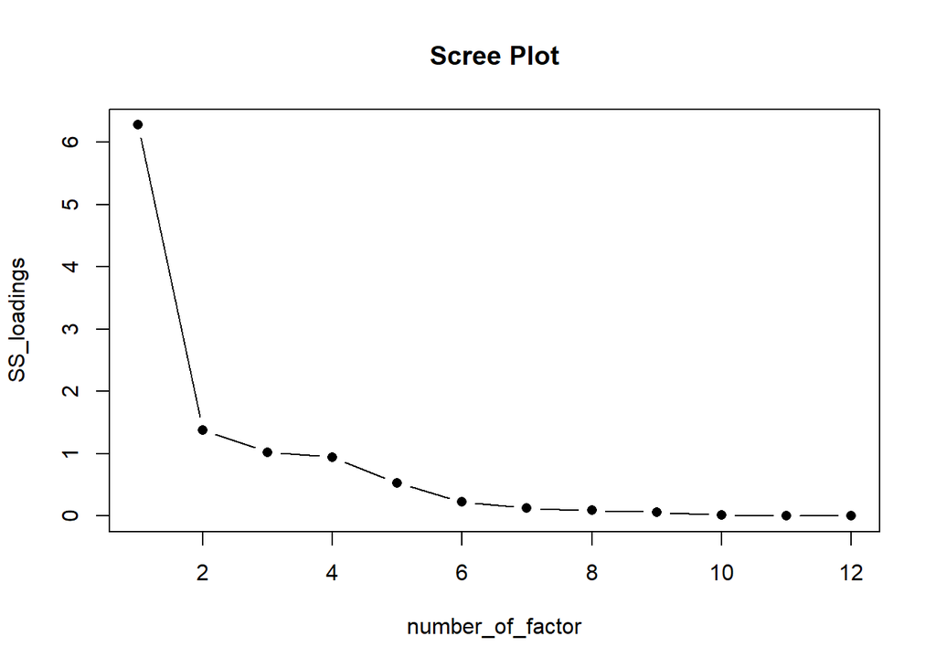

```r
SS_loadings <- fa_jobApp$Vaccounted[1,]
number_of_factor <- seq_along(SS_loadings)
plot(number_of_factor, SS_loadings, type = "b", main = "Scree Plot", pch = 16)
```

Berdasarkan *scree plot*, pola garis yang berbentuk seperti siku tangan berada pada factor kedua. Sehingga menurut *scree plot* cukup 2 factor saja yang digunakan.

Karena menurut *scree plot* dan *proportion of variance explained* berbeda, akan dicoba keduanya dan melihat factor mana yang lebih mudah diinterpretasikan.

## Tahap 3 - Estimasi Factor Loading (Menggunakan 4 Factor)

```r
fa_jobApp4 <- fa(data_jobApp, nfactors = 4, fm = "minres", rotate = "none")
print(fa_jobApp4$loadings, cut = 0)
```

```
##
## Loadings:
##                 MR1    MR2    MR3    MR4
## Academic.record  0.698  0.236 -0.304 -0.038
## Appearance       0.692 -0.222 -0.036  0.350
## Communication    0.696 -0.393  0.219 -0.211
## Company.Fit      0.786 -0.074 -0.042 -0.360
## Experience       0.623  0.489 -0.220  0.036
## Job.Fit          0.794  0.045 -0.113 -0.293
## Letter           0.633  0.411  0.599 -0.032
## Likeability      0.713 -0.240 -0.010  0.311
## Organization     0.703 -0.534  0.155 -0.231
## Potential        0.814  0.238 -0.400 -0.108
## Resume           0.708  0.353  0.424  0.216
## Self.Confidence  0.707 -0.251 -0.155  0.451
##
##                  MR1   MR2   MR3   MR4
## SS loadings    6.152 1.262 0.953 0.798
## Proportion Var 0.513 0.105 0.079 0.067
## Cumulative Var 0.513 0.618 0.697 0.764
```

Jika kita perhatikan, nilai factor loading yang besar berkumpul di peubah factor yang **pertama**, sehingga akan sulit untuk menginterpretasikan factor 2 sampai factor 4. Oleh karena itu, kita bisa melakukan rotasi faktor agar lebih mudah menginterpretasikanya.

| Note: |
| --- |
| Argumen `cut=0` berarti kita menampilkan semua factor loading, jika kita tidak tentukan isi dari argumen `cut`, secara default R tidak menampilkan nilai yang berkisar antara [-0.1, 0.1] |

## Tahap 3 - Estimasi Factor Loading (Menggunakan 2 Factor)

```r
fa_jobApp2 <- fa(data_jobApp, nfactors = 2, fm = "minres", rotate = "none")
print(fa_jobApp2$loadings, cut = 0)
```

```
##
## Loadings:
##                 MR1    MR2
## Academic.record  0.703  0.305
## Appearance       0.683 -0.172
## Communication    0.699 -0.434
## Company.Fit      0.778 -0.067
## Experience       0.637  0.578
## Job.Fit          0.792  0.063
## Letter           0.581  0.165
## Likeability      0.707 -0.198
## Organization     0.708 -0.548
## Potential        0.807  0.304
## Resume           0.670  0.187
## Self.Confidence  0.682 -0.143
##
##                  MR1   MR2
## SS loadings    5.993 1.169
## Proportion Var 0.499 0.097
## Cumulative Var 0.499 0.597
```

Untuk dua faktor pun, nilai factor loading yang besar terkumpul pada faktor pertama sehingga akan sulit diinterpretasikan. Oleh karena itu, kita akan melakukan rotasi faktor untuk penggunaan dua factor ini.

| Note: |
| --- |
| Ukuran besar atau kecil dari factor loading itu relatif. Beberapa buku menyebutkan nilai diatas 0.6 sudah besar. |

## Tahap 4 - Rotasi Factor (Menggunakan 4 Factor)

```r
fa_jobApp4_rotate <- fa(data_jobApp, nfactors = 4, fm = "minres", rotate = "varimax")
print(fa_jobApp4_rotate$loadings, cut = 0)
```

```
##
## Loadings:
##                 MR1    MR2    MR4    MR3
## Academic.record  0.713  0.178  0.269  0.154
## Appearance       0.230  0.272  0.704  0.171
## Communication    0.117  0.760  0.309  0.208
## Company.Fit      0.521  0.652  0.151  0.187
## Experience       0.732 -0.032  0.180  0.327
## Job.Fit          0.614  0.531  0.170  0.206
## Letter           0.223  0.243  0.059  0.904
## Likeability      0.226  0.321  0.688  0.185
## Organization     0.093  0.843  0.360  0.087
## Potential        0.855  0.257  0.285  0.118
## Resume           0.286  0.129  0.331  0.802
## Self.Confidence  0.273  0.210  0.816  0.085
##
##                  MR1   MR2   MR4   MR3
## SS loadings    2.757 2.392 2.211 1.806
## Proportion Var 0.230 0.199 0.184 0.151
## Cumulative Var 0.230 0.429 0.613 0.764
```

Setelah dirotasi menggunakan metode **varimax**, terlihat bahwa factor loadings tidak yang bernilai besar tidak lagi berkumpul pada satu faktor saja sehingga memungkinkan diinterpretasikan untuk setiap faktor yang terbentuk.

Fitur lain yang menarik untuk dibahas dalam analisis factor adalah *Communality*. *Communality* menjelaskan tentang banyaknya keragamaan yang dapat dijelaskan oleh factor untuk masing-masing peubah asal. Semakin nilainya mendekati satu semakin baik keragamaan yang dapat dijelaskan.

```r
fa_jobApp4_rotate$communalities
```

```
## Academic.record      Appearance   Communication     Company.Fit      Experience
##       0.6361963       0.6523914       0.7303190       0.7542383       0.6772272
##         Job.Fit          Letter     Likeability    Organization       Potential
##       0.7309871       0.9299102       0.6622484       0.8570245       0.8914205
##          Resume Self.Confidence
##       0.8520531       0.7911206
```

Dalam penggunan 4 factor ini nilai *communality* untuk semua peubah asal bernilai besar (lebih dari 0.6) sehingga dengan penggunaan 4 faktor sudah tepat.

## Tahap 4 - Rotasi Factor (Menggunakan 2 Factor)

```r
fa_jobApp2_rotate <- fa(data_jobApp, nfactors = 2, fm = "minres", rotate = "varimax")
print(fa_jobApp2_rotate$loadings, cut = 0)
```

```
##
## Loadings:
##                 MR1   MR2
## Academic.record 0.282 0.712
## Appearance      0.605 0.361
## Communication   0.802 0.187
## Company.Fit     0.598 0.503
## Experience      0.042 0.859
## Job.Fit         0.516 0.604
## Letter          0.294 0.527
## Likeability     0.640 0.359
## Organization    0.888 0.112
## Potential       0.356 0.785
## Resume          0.342 0.606
## Self.Confidence 0.584 0.381
##
##                  MR1   MR2
## SS loadings    3.583 3.579
## Proportion Var 0.299 0.298
## Cumulative Var 0.299 0.597
```

Untuk penggunaan dua factor juga akan nilai factor loadings yang besar sudah tersebar. Oleh karena itu memungkinkan diinterpretasikan.

```r
fa_jobApp2_rotate$communalities
```

```
## Academic.record      Appearance   Communication     Company.Fit      Experience
##       0.5867947       0.4963696       0.6774295       0.6104035       0.7404683
##         Job.Fit          Letter     Likeability    Organization       Potential
##       0.6313752       0.3644644       0.5383605       0.8015258       0.7437662
##          Resume Self.Confidence
##       0.4843980       0.4859770
```

Dalam penggunan 2 factor ini nilai *communality* untuk terdapat peubah asal bernilai kecil (kurang dari 0.4) sehingga dengan penggunaan 2 factor kurang tepat.

Dalam hal ini lebih baik menggunakan 4 factor saja, namun dalam ilustrasi ini 2 factor akan tetap digunakan untuk memperlihatkan perbedaan interpretasi dalam pemilihan banyaknya faktor digunakan.

| Note: |
| --- |
| *Communalities* bisa diperiksa saat sebelum kita melakukan rotasi. |

## Tahap 5 - Interpretasi Factor (Menggunakan 4 Factor)

Untuk mempermudah interpretasi, factor loading yang ditampilkan selain [-0.6, 0.6].

```r
print(fa_jobApp4_rotate$loadings, cut = 0.6)
```

```
##
## Loadings:
##                 MR1    MR2    MR4    MR3
## Academic.record  0.713
## Appearance                     0.704
## Communication           0.760
## Company.Fit             0.652
## Experience       0.732
## Job.Fit          0.614
## Letter                                0.904
## Likeability                    0.688
## Organization            0.843
## Potential        0.855
## Resume                                0.802
## Self.Confidence                0.816
##
##                  MR1   MR2   MR4   MR3
## SS loadings    2.757 2.392 2.211 1.806
## Proportion Var 0.230 0.199 0.184 0.151
## Cumulative Var 0.230 0.429 0.613 0.764
```

Pada penggunaan 4 factor, factor laoding hasil rotasi dapat diinterpretasikan sebagai berikut:

1. *Accademic Records*, *Experience*, *Job Fit*, dan *Potential* memiliki nilai factor loading yang besar dan positif untuk factor 1, kita bisa menyebut factor 1 sebagai **ketepatan penempatan dan potensi berkembang bagi pegawai dalam perusahaan**.
2. *Communication*, *Company Fit*, dan *Organization* memiliki nilai factor loading yang besar dan positif untuk factor 2 sehingga kita bisa menyebut factor 2 dengan **kemampuan dalam bekerja (*work skills*)**.
3. *Letter* dan *Resume* memiliki nilai factor loading yang besar dan positif untuk factor 3 sehingga kita bisa menyebut factor 3 dengan **kemampuan menulis**.
4. *Appearance*, *Likeability*, and *Self Confidence* memiliki nilai factor loading yang besar dan positif untuk faktor 4 sehingga kita bisa menyebut factor 4 dengan **kualitas personal pegawai**.

## Tahap 5 - Interpretasi Factor (Menggunakan 2 Factor)

```r
print(fa_jobApp2_rotate$loadings, cut = 0.6)
```

```
##
## Loadings:
##                 MR1   MR2
## Academic.record       0.712
## Appearance      0.605
## Communication   0.802
## Company.Fit
## Experience            0.859
## Job.Fit               0.604
## Letter
## Likeability     0.640
## Organization    0.888
## Potential             0.785
## Resume                0.606
## Self.Confidence
##
##                  MR1   MR2
## SS loadings    3.583 3.579
## Proportion Var 0.299 0.298
## Cumulative Var 0.299 0.597
```

Pada penggunaan 2 factor, factor laoding hasil rotasi dapat diinterpretasikan sebagai berikut:

1. *Appearance*, *Communication*, *Likeability*, dan *Organization* memiliki nilai factor loading yang besar dan positif untuk factor 1, kita bisa menyebut factor 1 sebagai *soft-skill* dari pegawai.
2. *Academic Record*, *Experience*, *Job Fit*, *Potential*, dan *Resume* memiliki nilai factor loading yang besar dan positif untuk factor 2, kita bisa menyebut factor 2 sebagai *hard-skill* dari pegawai.

Berdasarkan penggunaan 4 factor dan 2 factor diperoleh interpretasi yang berbeda dari factor-factor yang dihasilkan. Sehingga penggunaan 4 factor atau 2 factor bisa disesuaikan dengan kebutuhan perusahaan tersebut.

[output not shown]

# Pertemuan 9 Analisis Cluster

## K-Means

### Input data

Seorang pemilik Mall ingin mengelompokan customer di Mall yang ia miliki, sehingga tim marketing bisa mengembangkan strategi yang tepat untuk customer yang tepat pula. Data yang dimiliki oleh Mall tersebut adalah **Customer ID**, **umur pelanggan (*age*)**, **pendapatan tahunan dalam ribu dollar (*annual income*)**, dan *spending score*. Spending score merupakan nilai yang diberikan oleh Mall kepada customer berbasarkan perilaku customer (waktu kunjungan,jenis barang yang dibeli, dan banyaknya uang yang dihabiskan dalam belanja) yang memiliki rentang nilai 1-100. Semakin besar nilai Spending Score berarti customer semakin loyal pada Mall tersebut dan semakin besar pula uang belanja yang digunakan.

```r
library("factoextra")
data_mall <- read.csv("https://raw.githubusercontent.com/nurkhamidah/dat/main/mall_customers.csv", sep = ",")
head(data_mall)
```

```
##   CustomerID  Genre Age Annual.Income Spending.Score
## 1          1   Male  19            15             39
## 2          2   Male  21            15             81
## 3          3 Female  20            16              6
## 4          4 Female  23            16             77
## 5          5 Female  31            17             40
## 6          6 Female  22            17             76
```

## *Pre-processing* Data

Peubah yang digunakan untuk menerapkan K-Means adalah peubah `Age AnnualIncome` dan `Spending Score` (numerik). Oleh karena itu peubah yang tidak kita gunakan akan kita hilangkan tersebih dahulu.

```r
data_mall <- data_mall[,c("Age","Annual.Income","Spending.Score")]
head(data_mall)
```

```
##   Age Annual.Income Spending.Score
## 1  19            15             39
## 2  21            15             81
## 3  20            16              6
## 4  23            16             77
## 5  31            17             40
## 6  22            17             76
```

## Standardisasi Peubah

Standardisasi peubah merupakan proses transformasi peubah menjadi peubah yang memiliki rata-rata = 0 dan simpangan baku = 1. Proses standardisasi ini dilakukan jika kita melihat perbedaan satuan pengukuran peubah-peubah yang digunakan contoh (umur dan pendapatan). Standardisasi dilakukan karena metode K-Means menggunakan konsep jarak antara objek/amatan, yang mana sensitif terhadap satuan pengukuran. Formula untuk standardisasi data adalah sebagai berikut:

$y' = \frac{y-\bar{y}}{\sigma_y}$

Di mana:

- $\bar{y}$ : rataan $y$
- $\sigma_y$ : simpangan baku $y$

Dengan R, standardisasi dilakukan dengan fungsi `scale()`.

```r
data_mall_standardize <- scale(data_mall)
```

Jika kita perhatikan rata-rata peubah setelah distandardisasi mendekati nol.

```r
apply(data_mall_standardize, 2, mean)
```

```
##            Age  Annual.Income Spending.Score
##  -1.016906e-16  -8.144310e-17  -1.096708e-16
```

Dan simpangan baku dari peubah setelah distandardisasi mendekati satu.

```r
apply(data_mall_standardize, 2, sd)
```

```
##            Age  Annual.Income Spending.Score
##              1              1              1
```

[output not shown]

## Memilih Banyaknya Gerombol

Umumnya, banyaknya gerombol dapat ditentukan dengan menggunakan beberapa kriteria statistik, seperti koefisien *silhouette* dan **WSS** atau (*Within Sum of Square*).

- Kriteria koefisien *silhouette* dihitung berdasarkan jarak antar amatan. Koefisien ini mengukur seberapa dekat suatu amatan dengan amatan lain yang berada di gerombol yang sama (dikenal sebagai ukuran *cohesion*) dibandingkan dengan jarak terhadap amatan lain yang berada di gerombol berbeda (dikenal sebagai ukuran *separation*). Koefisien yang nilainya semakin besar menunjukkan bahwa gerombol yang terbentuk sudah sesuai.
- Kriteria WSS merupakan kriteria yang menghitung keragamaan dalam gerombol yang terbentuk. Semakin kecil keragaman dalam gerombol yang terbentuk menunjukkan bahwa gerombol yang terbentuk sudah sesuai.

Dengan menggunakan kriteria tersebut, kita bisa membandingkan banyaknya gerombol yang paling sesuai pada data yang kita sedang analisis. Dalam R, fungsi `fviz_nbclust()` dari *package* 1factoextra1 dapat digunakan untuk memilih banyaknya gerombol.

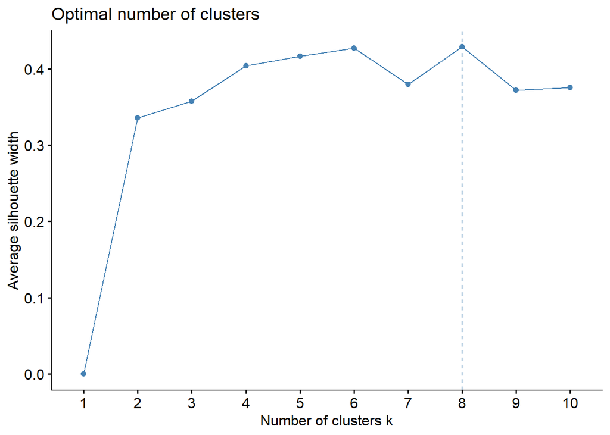

```r
fviz_nbclust(data_mall_standardize, FUNcluster = kmeans, method = "silhouette")
```

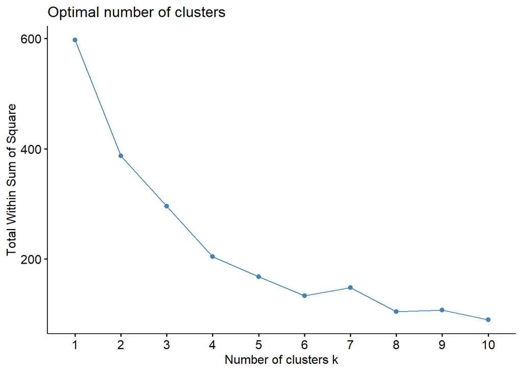

```r
fviz_nbclust(data_mall_standardize, FUNcluster = kmeans, method = "wss")
```

Untuk kriteria koefisien *silhouette*, banyaknya gerombol dengan **nilai koefisien tertinggi** yang kita pilih. Sedangkan pada WSS, banyaknya gerombol yang kita pilih didasarkan pada banyaknya gerombol yang mana garisnya **berbentuk seperti siku (*elbow*)**. Pada gambar diatas garis membentuk siku saat berada di gerombol keempat. **Karena penentuan ini berdasarkan visual, jadi setiap orang mungkin berbeda melihat pola sikunya.**

Berdasarkan kedua kriteria tersebut, banyaknya gerombol terbaik yang dipilih berbeda. Jika demikian, banyaknya gerombol bisa ditentukan berdasarkan kemudahan interpretasi gerombol yang terbentuk. Pada tulisan ini kita akan menggunakan 4 gerombol saja.

[output not shown]

## Menerapkan K-Means

Setelah kita mendapatkan banyaknya gerombol terbaik, maka selajutnya kita akan menerapkan metode K-Means untuk mendapatkan label gerombol pada setiap amatan. Fungsi eclust dari *package* `factoextra` digunakan untuk menerpkan metode K-Means. Pada fungsi `eclust()`, kita cukup memasukan data yang sebelum distandardisasi, karena dalam fungsi tersebut terdapat argumen `stand`, yang jika diatur `stand = TRUE` secara otomatis data yang kita gunakan akan distandardisasi.

```r
kmeans_mall <- eclust(data_mall, stand = TRUE, FUNcluster = "kmeans", k=4, graph = F)
```

Memanggil label gerombol untuk setiap amatan dilakukan dengan:

```r
kmeans_mall$cluster
```

```
##   [1] 3 3 3 3 3 3 2 3 2 3 2 3 2 3 2 3 3 3 2 3 3 3 2 3 2 3 2 3 2 3 2 3 2 3 2 3 2
##  [38] 3 2 3 2 3 2 3 2 3 2 3 3 3 2 3 3 2 2 2 2 2 3 2 2 3 2 2 2 3 2 2 3 3 2 2 2 2
##  [75] 2 3 2 2 3 2 2 3 2 2 3 2 2 3 3 2 2 3 2 2 3 3 2 3 2 3 3 2 2 3 2 3 2 2 2 2 2
## [112] 3 1 3 3 3 2 2 2 2 3 1 4 4 1 4 1 4 2 4 1 4 1 4 1 4 1 4 1 4 1 4 1 4 1 4 1 4
## [149] 1 4 1 4 1 4 1 4 1 4 1 4 2 4 1 4 1 4 1 4 1 4 1 4 1 4 1 4 1 4 1 4 1 4 1 4 1
## [186] 4 1 4 1 4 1 4 1 4 1 4 1 4 1 4
```

Kemu- dian,interpretasi setiap gerombol yang terbentuk dapat dilakukan dengan menggunakan bantuan nilai rata-rata dari masing-masing peubah dihitung berdasarkan gerombol. Informasi ini bisa diperoleh dengan menggunakan `$centers`. Karena kita melakukan standardisasi peubah, maka nilai rata-rata yang diperoleh juga dalam skala standardisasi.

```r
kmeans_mall$centers
```

```
##           Age Annual.Income Spending.Score
## 1  0.03711223     0.9876366     -1.1857814
## 2  1.08344244    -0.4893373     -0.3961802
## 3 -0.96008279    -0.7827991      0.3910484
## 4 -0.42773261     0.9724070      1.2130414
```

## Interpretasi Gerombol yang terbentuk

Jika sulit membaca hasil dalam bentuk skala standardisasi maka kita bisa menggunakan fungsi `aggregate()` untuk melihat rata-ratanya dalam skala aslinya. Fungsi ini dapat menghitung rata-rata setiap peubah berdasarkan gerombol yang terbentuk.

```r
aggregate(data_mall, by =list(gerombol = kmeans_mall$cluster), FUN = mean)
```

```
##   gerombol      Age Annual.Income Spending.Score
## 1        1 39.36842      86.50000       19.57895
## 2        2 53.98462      47.70769       39.96923
## 3        3 25.43860      40.00000       60.29825
## 4        4 32.87500      86.10000       81.52500
```

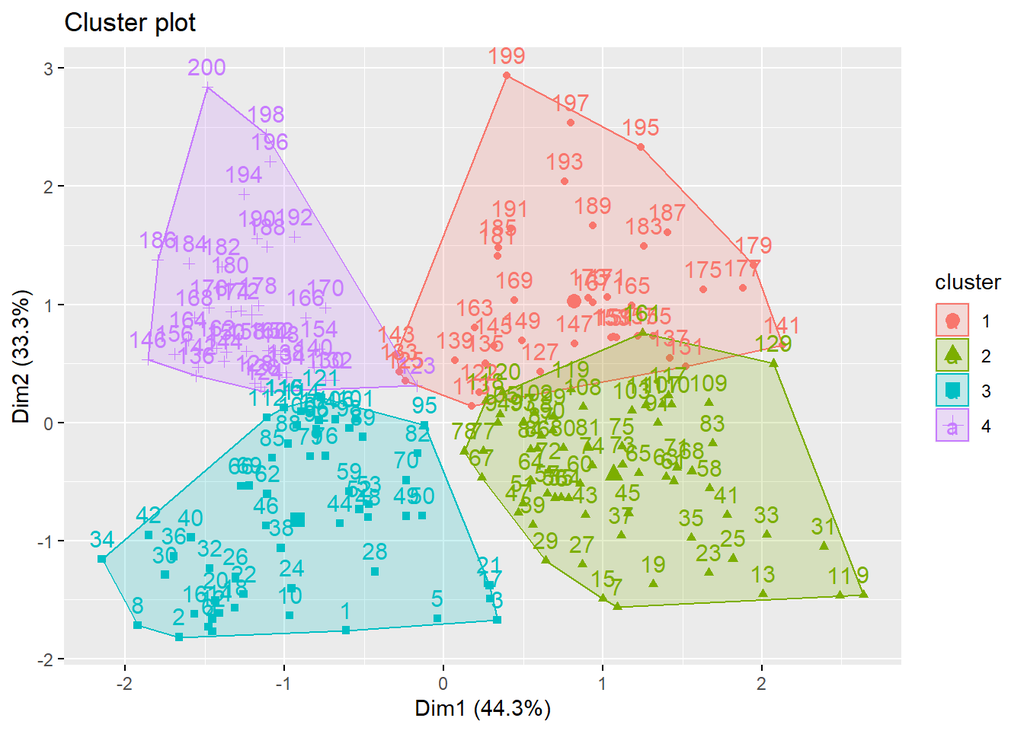

```r
fviz_cluster(kmeans_mall)
```

Cara lain untuk menginterpretasikan hasil gerombol adalah menggunakan scatterplot. Jika peubah untuk membangun cluster lebih dari dua, maka sebelum dibentuk *scatterplot* peubah tersebut direduksi terlebih dahulu menggunakan analisis komponen utama menjadi dua komponen utama. Namun, untuk interpretasinya setiap gerombolnya kita harus mengetahui interpretasi dari kedua komponen utama dan belum tentu dengan dua komponen utama tersebut sudah mampu menjelaskan keragaman data asal dengan baik.

Interpretasi dua komponen utama bisa dilihat dengan akar cirinya.

```r
pca_mall <- prcomp(data_mall_standardize)
pca_mall$rotation
```

```
##                        PC1         PC2          PC3
## Age             0.70638235  0.03014116 -0.707188441
## Annual.Income  -0.04802398  0.99883160 -0.005397916
## Spending.Score -0.70619946 -0.03777499 -0.707004506
```

## Profiling cluster

```r
# Ambil data centeroids
centers <- kmeans_mall$centers

# Konvert data centeroids ke data frame
centers_df <- as.data.frame(centers)

# Tambahkan Kolom Kluster
centers_df$cluster <- rownames(centers_df)

# Konversi Data Wide ke Long
library(tidyr)
centers_long <- gather(centers_df, key = "variable", value = "value", -cluster)
```

[figure not shown]

```r
# Plot the cluster profiles
library(ggplot2)
ggplot(centers_long, aes(x = cluster, y = value, fill = variable)) +
  geom_bar(stat = "identity", position = "dodge") +
  labs(x = "Cluster", y = "Mean Value", fill = "Variable") +
  theme_minimal() +
  theme(plot.title = element_text(hjust = 0.5)) +
  ggtitle("Profil Klaster Rata-rata Pengeluaran Perkapita Seminggu Menurut \n Kelompok Daging di Jawa Barat Menurut Kabupaten/Kota di Jawa Barat")
```

Jika sulit membaca hasil dalam bentuk skala standardisasi maka kita bisa menggunakan fungsi `aggregate()` untuk melihat rata-ratanya dalam skala aslinya. Fungsi ini dapat menghitung rata-rata setiap peubah berdasarkan gerombol yang terbentuk.

## *Hierarchical Clustering*

*Hierarchical clustering* menghasilkan hierarki yang dapat dilihat dalam bentuk dendrogram. Dendrogram ini menunjukkan cara objek-objek tersebut dikelompokkan dalam kelompok-kelompok yang berjenjang, dan dapat dipilih sejauh mana tingkat hierarki yang ingin dieksplorasi dengan memotong dendrogram pada tingkat yang sesuai.

Dua jenis *hierarchical clustering*:

- **Agglomerative Clustering** : Dalam metode *agglomerative*, proses dimulai dengan menganggap setiap objek sebagai kelompok tunggal, dan kemudian objek-objek tersebut bergabung dalam kelompok yang semakin besar berdasarkan kesamaan mereka.
- **Divisive Clustering** : Dalam metode *divisive*, proses dimulai dengan menganggap semua objek sebagai satu kelompok besar, dan kemudian kelompok ini dibagi menjadi kelompok yang semakin kecil berdasarkan perbedaan antara objek-objeknya.

Pemilihan jenis *linkage* (cara mengukur jarak antara kelompok) dalam *hierarchical clustering* adalah keputusan penting dalam analisis gerombol ini. *Linkage* mempengaruhi bagaimana kelompok-kelompok dibentuk dan hierarki yang dihasilkan dalam dendrogram. Beberapa jenis *linkage* antara lain:

1. *Single linkage* (berdasarkan jarak terdekat antara anggota kelompok)
2. *Complete linkage* (berdasarkan jarak terjauh antara anggota kelompok)
3. *Average linkage* (berdasarkan jarak rataan antara anggota kelompok)
4. *Ward’s Method* (berdasarkan variansi dalam anggota kelompok)
5. *Centroid Linkage* (berdasarkan centroid antara anggota kelompok)

Tahap analisis gerombol dengan *hierarchical clustering*: 1. *Pre-processing* data 2. Memilih metode *linkage* dan banyaknya gerombol 3. Menerapkan *Hierarchical Clustering* 4. Interprestasi gerombol yang terbentuk

### Contoh Kasus

Contoh kasus yang digunakan adalah kasus yang sama dengan contoh sebelumnya, dengan data yang dipakai adalah data numerik yang distandardisasi sebagaimana data pada contoh sebelumnya.

```r
head(data_mall_standardize)
```

```
##             Age Annual.Income Spending.Score
## [1,] -1.4210029     -1.734646     -0.4337131
## [2,] -1.2778288     -1.734646      1.1927111
## [3,] -1.3494159     -1.696572     -1.7116178
## [4,] -1.1346547     -1.696572      1.0378135
## [5,] -0.5619583     -1.658498     -0.3949887
## [6,] -1.2062418     -1.658498      0.9990891
```

### Memilih Metode *Linkage* Banyaknya Gerombol

Untuk memilih metode linkage dan banyaknya gerombol bisa menggunakan

1. Koefisien *silhoutte* dan WSS (seperti K-Means)
2. Menggunakan dendogram

### Menggunakan koefisien *silhouette* dan WSS

Untuk ilustrasi kita akan menggunakan metode *silhouette* saja karena lebih mudah menentukan jumlah gerombolnya.

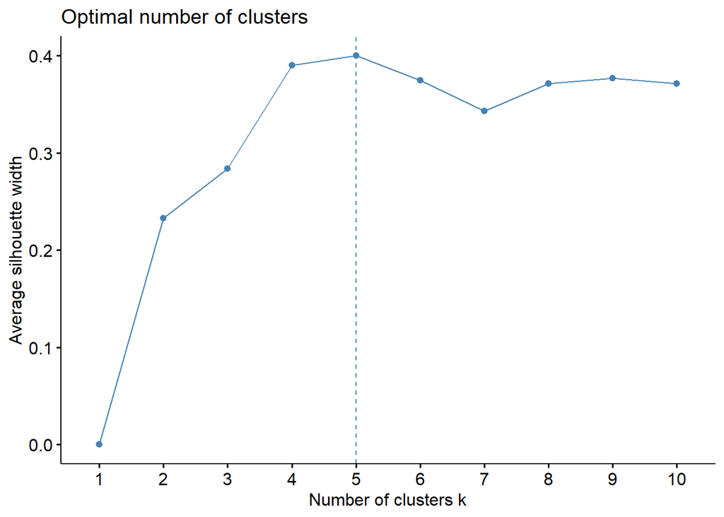

```r
# complete
fviz_nbclust(data_mall_standardize, FUNcluster = hcut, method = "silhouette", hc_method = "complete", hc_metric = "euclidean")
```

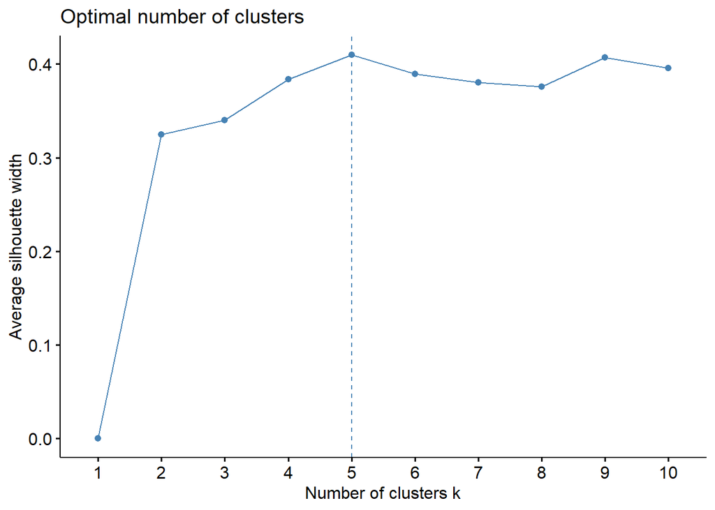

```r
# average
fviz_nbclust(data_mall_standardize, FUNcluster = hcut, method = "silhouette", hc_method = "average", hc_metric = "euclidean")
```

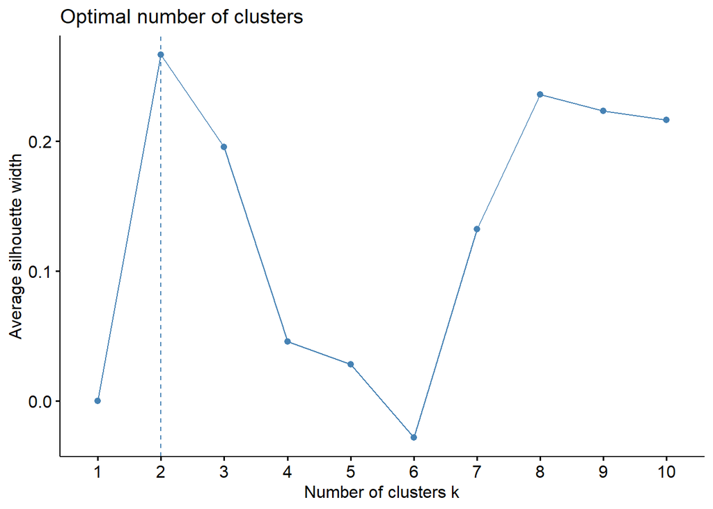

```r
# centroid
fviz_nbclust(data_mall_standardize, FUNcluster = hcut, method = "silhouette", hc_method = "centroid", hc_metric = "euclidean")
```

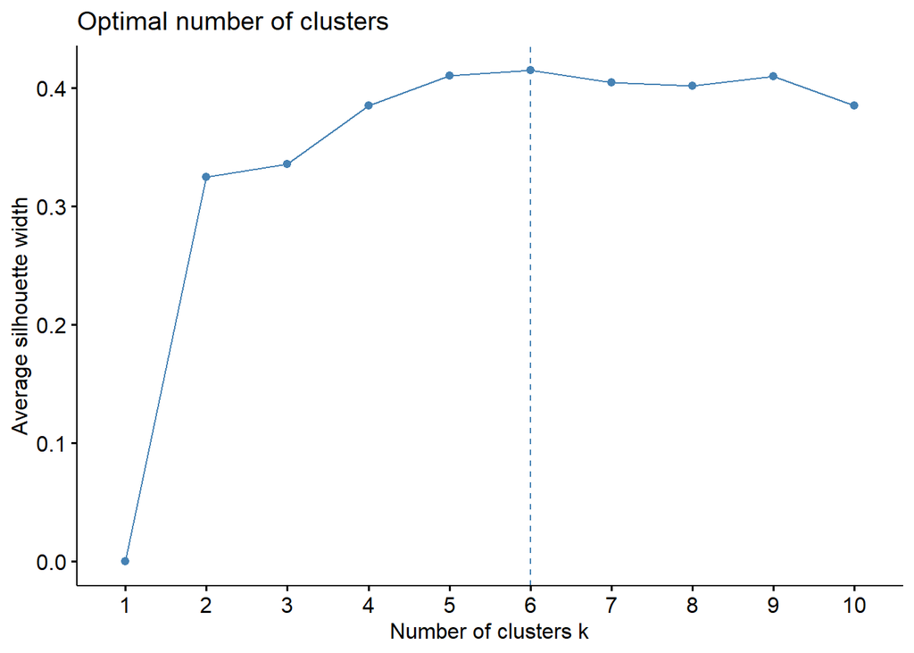

```r
# ward
fviz_nbclust(data_mall_standardize, FUNcluster = hcut, method = "silhouette", hc_method = "ward.D", hc_metric = "euclidean")
```

Berdasarkan koefisien *silhouette*, metode *complete* dan *average* memilih 5 gerombol, sedangkan metode *centroid* dan *ward* masing-masing memilih 2 dan 6 gerombol. Untuk saat ini, kita akan mencoba menggunakan 5 gerombol dengan metode *complete* (Jika dua metode *linkage* memilih banyaknya gerombol yang sama, gerombol yang terbentuk akan relatif mirip, oleh karena itu bisa pilih salah satu).

### Menggunakan dendogram

Penggunaan dendogram untuk data yang memiliki amatan yang banyak mungkin tidak efektif karena memilih gerombol dengan dendogram dilakukan secara visual.

```r
linkage_methods <- c("complete", "average", "centroid", "ward.D")
hc_mall_dend <- lapply(linkage_methods, function(i)
    hclust(dist(data_mall_standardize, method = 'euclidean'), method = i)
    )
```

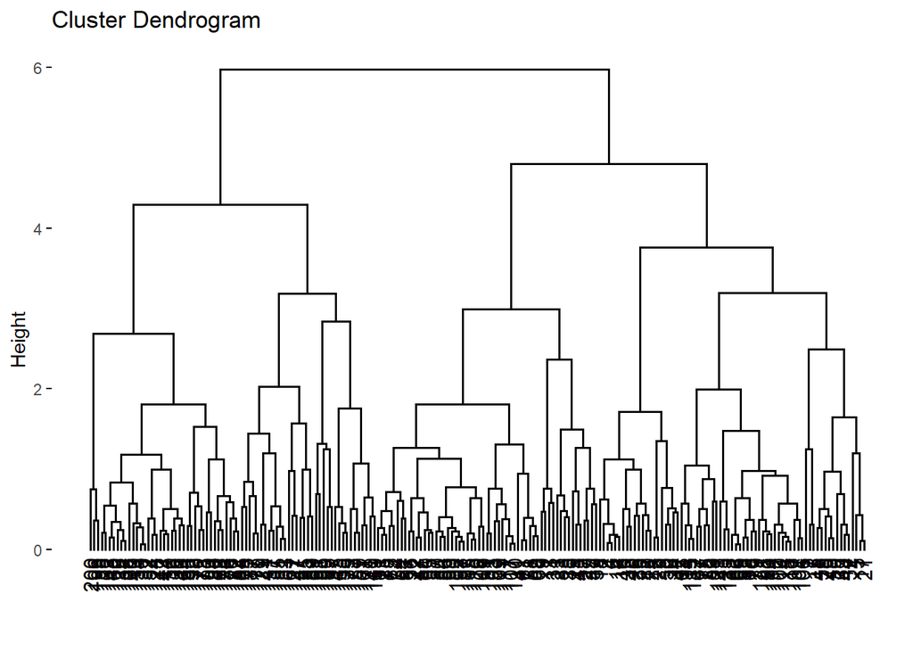

```r
# complete
fviz_dend(hc_mall_dend[[1]])
```

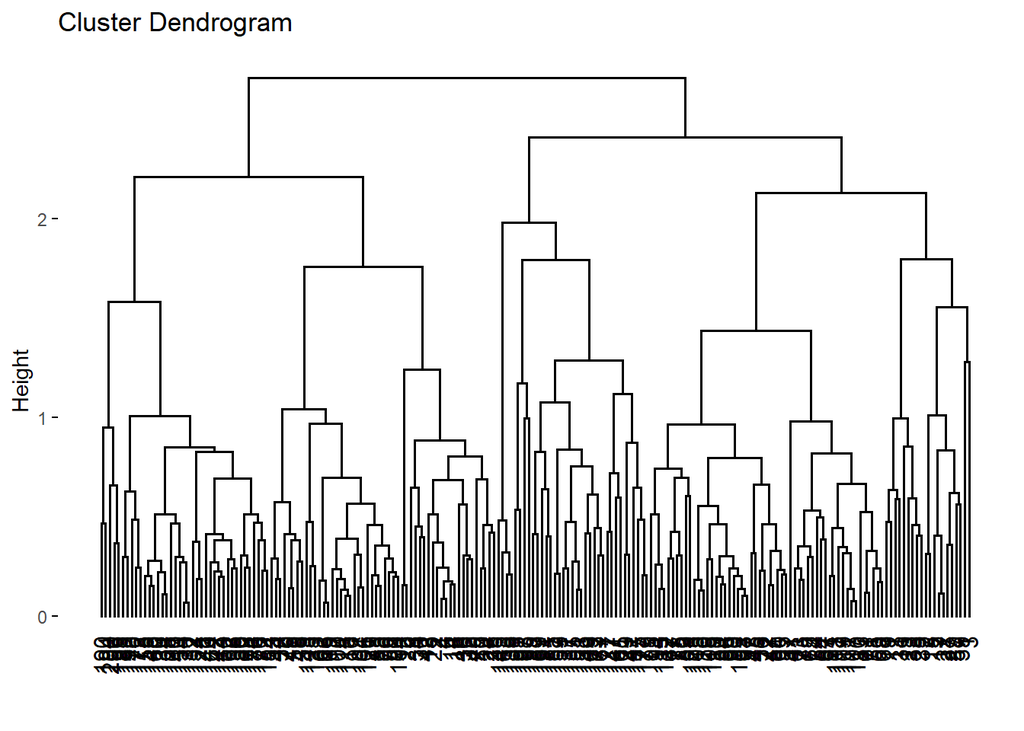

```r
# average
fviz_dend(hc_mall_dend[[2]])
```

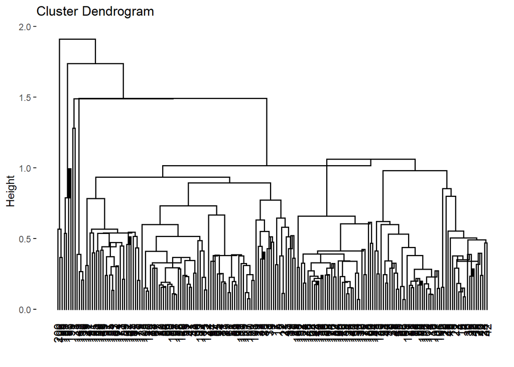

```r
# centroid
fviz_dend(hc_mall_dend[[3]])
```

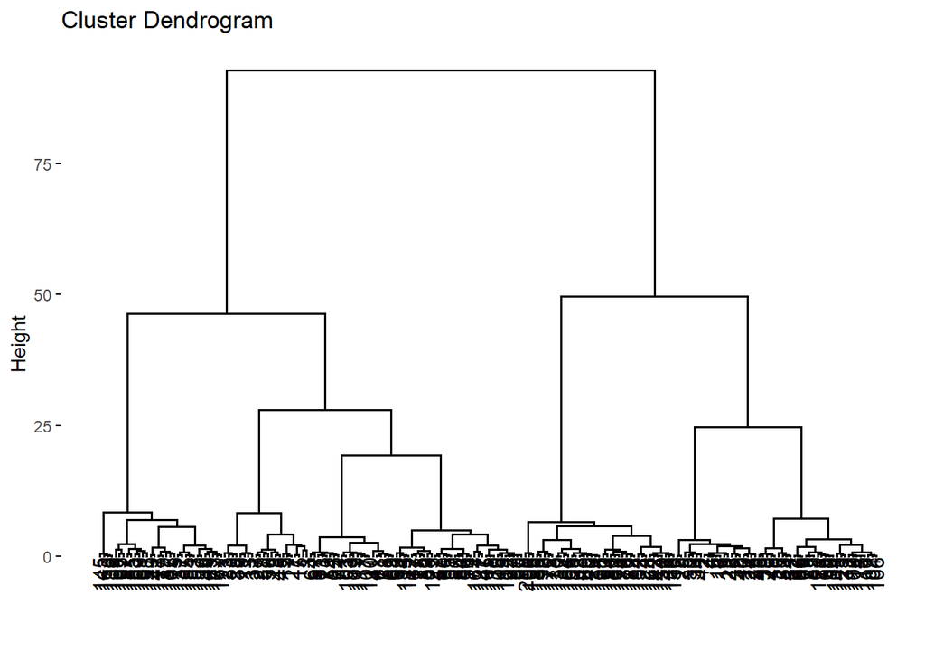

```r
# ward
fviz_dend(hc_mall_dend[[4]])
```

Jika diperhatikan dari keempat dendogram pada masing-masing metode *linkage*, banyaknya gerombol yang terbentuk sama seperti menggunakan keofisien *silhouette* diatas.

### Menerapkan *Hierarchical Clustering*

```r
hc_mall <- eclust(data_mall,stand = TRUE,FUNcluster = "hclust", k=5, hc_method = "complete", hc_metric = "euclidean")
hc_mall$cluster
```

```
##   [1] 1 2 1 2 1 2 1 2 3 2 3 2 3 2 1 2 1 2 3 2 1 2 3 2 3 2 3 1 3 2 3 2 3 2 3 2 3
##  [38] 2 3 2 3 2 3 1 3 2 3 1 1 1 3 1 1 3 3 3 3 3 1 3 3 1 3 3 3 1 1 3 1 1 3 3 3 3
##  [75] 3 1 1 1 1 3 3 1 3 3 1 3 3 1 1 3 3 1 3 1 1 1 3 1 3 1 1 3 3 1 3 1 3 3 3 3 3
## [112] 1 1 1 1 1 3 3 3 3 1 1 1 4 1 4 5 4 5 4 5 4 1 4 5 4 5 4 5 4 5 4 1 4 5 4 5 4
## [149] 5 4 5 4 5 4 5 4 5 4 5 4 5 4 5 4 5 4 5 4 5 4 5 4 5 4 5 4 5 4 5 4 5 4 5 4 5
## [186] 4 5 4 5 4 5 4 5 4 5 4 5 4 5 4
```

### Interprestasi Gerombol yang terbentuk

Coba lakukan interpretasi gerombol seperti metode kmeans diatas.

```r
aggregate(data_mall,by =list(gerombol=hc_mall$cluster), FUN = mean)
```

```
##   gerombol      Age Annual.Income Spending.Score
## 1        1 28.35417      50.29167       45.93750
## 2        2 24.80952      25.61905       80.23810
## 3        3 55.33333      47.31579       41.08772
## 4        4 32.69231      86.53846       82.12821
## 5        5 41.68571      88.22857       17.28571
```

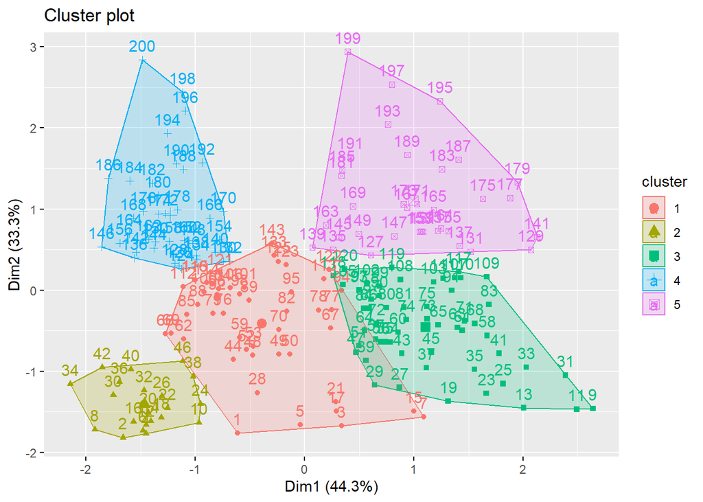

```r
fviz_cluster(hc_mall)
```

Interpretasi dua komponen utama bisa dilihat dengan akar cirinya.

```r
pca_mall <- prcomp(data_mall_standardize)
pca_mall$rotation
```

```
##                        PC1         PC2          PC3
## Age             0.70638235  0.03014116 -0.707188441
## Annual.Income  -0.04802398  0.99883160 -0.005397916
## Spending.Score -0.70619946 -0.03777499 -0.707004506
```

# Pertemuan 10 Analisis Diskriminan

## Langkah-langkah Analisis Diskriminan

Analisis diskriminan dilakukan dengan langkah-langkah berikut:

1. Membagi data menjadi dua bagian: data latih (*train data*) dan data uji (*test data*) Cara untuk membagi dapat dilakukan dengan pengambilan acak. Proporsi data latih dapat sebesar 70% atau 80% dari data asal. Misal, jika memiliki data dengan 100 amatan, maka dipilih secara acak 70 atau 80 amatan sebagai data latihnya. Tujuan dari pembagian data adalah untuk mengukur dan memastikan seberapa baik model yang dibangun dalam memprediksi data yang tidak pernah dilakukan pemodelan sebelumnya. Data latih dipakai untuk membangun model, data uji dipakai untuk menguji kemampuan model yang dibangun.
2. Dengan menggunakan data latih, lakukan:
   1. Uji normal ganda
   2. Uji asumsi kesamaan ragam. Jika uji ini menghasilkan kesimpulan matriks ragam-peragam sama, maka digunakan *Linear Discriminant Analisis* (LDA). Jika tidak, maka digunakan *Quadratic Discriminant Analisis* (QDA).

   Catatan:

   Menurut Mattjik dan Sumertajaya pada buku Sidik Peubah Ganda, “umumnya sangat sulit sekali untuk dapat memenuhi persyaratan (a) dan (b), yang dalam praktek sering kali tidak diuji; hal mana akan membuat akurasi dari analisis dengan fungsi diskriminan akan berkurang. Namun demikian, fungsi diskriminan selalu menghasilkan estimasi yang kokoh (*robust estimates*) terutama yang berkaitan dengan prediksi pengelompokan”.
   3. Estimasi koefisien analisis diskriminan
   4. Evaluasi kemampuan klasifikasi analisis diskriminan
3. Evaluasi kemampuan klasifikasi menggunakan data uji

```r
library(rattle)
library(caret)
library(MVN)
```

```r
library(heplots)
library(MASS)
```

## Input Data

Dataset *Wine* ini berisi hasil analisis kimia anggur yang tumbuh di daerah tertentu di Italia. Tiga jenis anggur direpresentasikan dalam 178 sampel, dengan hasil dari 13 analisis kimia yang dicatat untuk setiap sampel. Peubah `Type` telah diubah menjadi peubah kategorik.

```r
data(wine, package = "rattle")
head(wine)
```

```
##   Type Alcohol Malic  Ash Alcalinity Magnesium Phenols Flavanoids Nonflavanoids
## 1    1   14.23  1.71 2.43       15.6       127    2.80       3.06          0.28
## 2    1   13.20  1.78 2.14       11.2       100    2.65       2.76          0.26
## 3    1   13.16  2.36 2.67       18.6       101    2.80       3.24          0.30
## 4    1   14.37  1.95 2.50       16.8       113    3.85       3.49          0.24
## 5    1   13.24  2.59 2.87       21.0       118    2.80       2.69          0.39
## 6    1   14.20  1.76 2.45       15.2       112    3.27       3.39          0.34
##   Proanthocyanins Color  Hue Dilution Proline
## 1            2.29  5.64 1.04     3.92    1065
## 2            1.28  4.38 1.05     3.40    1050
## 3            2.81  5.68 1.03     3.17    1185
## 4            2.18  7.80 0.86     3.45    1480
## 5            1.82  4.32 1.04     2.93     735
## 6            1.97  6.75 1.05     2.85    1450
```

```r
dim(wine)
```

```
## [1] 178  14
```

Diperoleh bahwa data terdiri dari 13 peubah prediktor dan 1 peubah respon sebagai berikut:

| Nama peubah | Keterangan |
| --- | --- |
| `Type` | Tipe anggur, terdiri dari: 1 (59 amatan), 2 (71 amatan), dan 3 (48 amatan) |
| `Alcohol` | Kadar alkohol |
| `Malic` | Kadar asam malat |
| `Ash` | Abu |
| `Alcalinity` | Alkalinitas abu |
| `Magnesium` | Kadar Magnesium |
| `Phenols` | Total fenol |
| `Flavonoids` | Kadar fenol flavonoid |
| `Nonflavonoids` | Kadar fenol nonflavonoid |
| `Proanthocyanins` | Proantosianidin |
| `Color` | Intensitas warna |
| `Hue` | Spektrum warna |
| `Dilution` | Dilusi anggur D280/OD315 |
| `Proline` | Kadar prolin |

Menampilkan sebagian data dan tipe peubahnya sebagai berikut:

```r
glimpse(wine)
```

```
## Rows: 178
## Columns: 14
## $ Type            <fct> 1, 1, 1, 1, 1, 1, 1, 1, 1, 1, 1, 1, 1, 1, 1, 1, 1, 1, …
## $ Alcohol         <dbl> 14.23, 13.20, 13.16, 14.37, 13.24, 14.20, 14.39, 14.06…
## $ Malic           <dbl> 1.71, 1.78, 2.36, 1.95, 2.59, 1.76, 1.87, 2.15, 1.64, …
## $ Ash             <dbl> 2.43, 2.14, 2.67, 2.50, 2.87, 2.45, 2.45, 2.61, 2.17, …
## $ Alcalinity      <dbl> 15.6, 11.2, 18.6, 16.8, 21.0, 15.2, 14.6, 17.6, 14.0, …
## $ Magnesium       <int> 127, 100, 101, 113, 118, 112, 96, 121, 97, 98, 105, 95…
## $ Phenols         <dbl> 2.80, 2.65, 2.80, 3.85, 2.80, 3.27, 2.50, 2.60, 2.80, …
## $ Flavanoids      <dbl> 3.06, 2.76, 3.24, 3.49, 2.69, 3.39, 2.52, 2.51, 2.98, …
## $ Nonflavanoids   <dbl> 0.28, 0.26, 0.30, 0.24, 0.39, 0.34, 0.30, 0.31, 0.29, …
## $ Proanthocyanins <dbl> 2.29, 1.28, 2.81, 2.18, 1.82, 1.97, 1.98, 1.25, 1.98, …
## $ Color           <dbl> 5.64, 4.38, 5.68, 7.80, 4.32, 6.75, 5.25, 5.05, 5.20, …
## $ Hue             <dbl> 1.04, 1.05, 1.03, 0.86, 1.04, 1.05, 1.02, 1.06, 1.08, …
## $ Dilution        <dbl> 3.92, 3.40, 3.17, 3.45, 2.93, 2.85, 3.58, 3.58, 2.85, …
## $ Proline         <int> 1065, 1050, 1185, 1480, 735, 1450, 1290, 1295, 1045, 1…
```

## Tahap 1 : Membagi data menjadi data latih dan data uji

Pembagian data dapat dilakukan dengan menggunakan fungsi `createDataPartition()` dari pacakge `caret`. Sintaks `caret::createDataPartition()` berarti kita memanggil fungsi `createDataPartition()` dari `caret` tanpa perlu memanggil *package* `caret` menggunakan `library(caret)`. Argumen `y` merupakan peubah respon/gerombol, `p` merupakan proporsi data latih (dalam hal ini 0.7 atau 70%), `list=FALSE` berarti hasil output dari `createDataPartition()` disimpan dalam bentuk vektor (defaultnya `list=TRUE`)

```r
set.seed(123)
index_train <- caret::createDataPartition(y = wine$Type, p = 0.7, list = FALSE)
wine_train <- wine[index_train,]
wine_test <- wine[-index_train,]
```

`index_train` berisi vektor dari urutan/indeks amatan (1, 2, …, dst) yang telah dilakukan pengambilan contoh secara acak.

## Tahap 2 : Pembangunan model dengan data latih

Dengan menggunakan data latih yang telah diambil, dilakukan langkah berikut:

### 1. Uji normalitas ganda

[output not shown]

### 2. Uji kesamaan ragam

[output not shown]

### 3. Estimasi koefisien analisis diskriminan

[output not shown]

### 4. Evaluasi kemampuan klasifikasi analisis diskriminan

[output not shown]

```r
 # QDA
    table(wine_train$Type, predict_qda$class)
```

```
##
##      1  2  3
##   1 42  0  0
##   2  0 50  0
##   3  0  0 34
```

[output not shown]

## Tahap #3 : Evaluasi kemampuan klasifikasi model dengan data uji

Pada tahap terakhir ini akan dilakukan evaluasi kemampuan klasifikasi jika seandainya terdapat data baru yang tidak terlibat dalam proses pemodelan. Sebelum mengevaluasi kedua model, maka akan dilakukan ekstraksi prediksi gerombol yang dihasilkan oleh kedua model pada data baru ini. Argumen `newdata` disi dengan data baru (data uji).

```r
predict_lda_test <- predict(wine_lda, newdata = wine_test)
predict_qda_test <- predict(wine_qda, newdata = wine_test)
```

Diperoleh tabel klasifikasi berikut:

```r
# LDA
table(wine_test$Type, predict_lda_test$class)
```

```
##
##      1  2  3
##   1 17  0  0
##   2  0 21  0
##   3  0  1 13
```

```r
# QDA
table(wine_test$Type,predict_qda_test$class)
```

```
##
##      1  2  3
##   1 17  0  0
##   2  0 21  0
##   3  0  0 14
```

Berdasarkan tabel klasifikasi diatas, terlihat bahwa model LDA masih memiliki kesalahan prediksi gerombol. Kesahalahan prediksi ini terjadi pada gerombol 3, dimana diprediksi gerombolnya 2.

Kesalahan klasifikasi dihitung dengan:

```r
#LDA
sum(wine_test$Type!=predict_lda_test$class)/length(predict_lda_test$class)
```

```
## [1] 0.01923077
```

```r
#QDA
sum(wine_test$Type!=predict_qda_test$class)/length(predict_qda_test$class)
```

```
## [1] 0
```

Berdasarkan tingkat kesalahan klasifikasi model QDA memiliki tingkat kesalahan klasifikasi yang lebih kecil sehingga dapat dikatakan model QDA lebih baik daripada model LDA. Hal ini selaras dengan model QDA yang lebih cocok digunakan sesuai dengan uji keterpenuhan asumsi yang telah dilakukan sebelumnya.

Untuk melihat amatan mana yang disalahklasifikasikan oleh LDA, dilakukan dengan melihat kelas hasil prediksi data ujinya.

```r
cbind(wine_test, Type_pred = predict_lda_test$class)[wine_test$Type != predict_lda_test$class,]
```

```
##     Type Alcohol Malic  Ash Alcalinity Magnesium Phenols Flavanoids
## 131    3   12.86  1.35 2.32         18       122    1.51       1.25
##     Nonflavanoids Proanthocyanins Color  Hue Dilution Proline Type_pred
## 131          0.21            0.94   4.1 0.76     1.29     630         2
```

| Catatan: |
| --- |
| Note Dalam praktiknya data baru yang dimaksud belum memiliki gerombol asli, sehingga tidak memungkinkan untuk dilakukan evaluasi. |

## Studi Kasus 2

- Sebuah Program Pascasarjana di sebuah perguruan tinggi melakukan evaluasi terhadap keberhasilan studi mahasiswa S2 di semester pertama.
- Data menunjukkan bahwa ada tiga pengelompokan status mahasiswa yang berkaitan dengan kelanjutan studi di semester 2, yaitu Lanjut ke semester 2, Pindah ke program studi lain, dan Drop Out.
- Banyak mahasiswa yang tidak dapat melanjutkan ke semester dua dengan lancar, diduga karena kurang seleksinya kualitas input mahasiswa.
- Oleh karena itu, Ketua Program Studi tersebut berencana membuat kriteria seleksi untuk menyaring mahasiswa yang berkualitas.
- Variabel yang digunakan sebagai dasar penentuan kriteria seleksi adalah IPK S1 dan skor hasil tes masuk S2. Lakukan analisis yang sesuai untuk tujuan tersebut.

### Menyiapkan Data

```r
data_ipk <- read.csv("https://raw.githubusercontent.com/nurkhamidah/dat/main/data-ipk.csv", sep = ";")
head(data_ipk)
```

```
##    IPK Skor.tes Status
## 1 2.96      596 Lanjut
## 2 3.14      473 Lanjut
## 3 3.22      482 Lanjut
## 4 3.29      527 Lanjut
## 5 3.69      505 Lanjut
## 6 3.46      693 Lanjut
```

```r
# merubah "Status" menjadi peubah kategorik
data_ipk$Status <- as.factor(data_ipk$Status)
glimpse(data_ipk)
```

```
## Rows: 85
## Columns: 3
## $ IPK      <dbl> 2.96, 3.14, 3.22, 3.29, 3.69, 3.46, 3.03, 3.19, 3.63, 3.59, 3…
## $ Skor.tes <int> 596, 473, 482, 527, 505, 693, 626, 663, 447, 588, 563, 553, 5…
## $ Status   <fct> Lanjut, Lanjut, Lanjut, Lanjut, Lanjut, Lanjut, Lanjut, Lanju…
```

```r
summary(data_ipk)
```

```
##       IPK           Skor.tes          Status
##  Min.   :2.130   Min.   :313.0   Drop Out:28
##  1st Qu.:2.600   1st Qu.:425.0   Lanjut  :31
##  Median :3.010   Median :482.0   Pindah  :26
##  Mean   :2.975   Mean   :488.4
##  3rd Qu.:3.300   3rd Qu.:538.0
##  Max.   :3.800   Max.   :693.0
```

Membagi data menjadi data latih dan data uji dengan proporsi 80:20 sebagai berikut:

```r
set.seed(1)
index_train <- caret::createDataPartition(y = data_ipk$Status, p = 0.8, list = FALSE)
ipk_train <- data_ipk[index_train,]
ipk_test <- data_ipk[-index_train,]
```

### Membangun model dengan data latih

- Uji normalitas ganda

  H0 : data menyebar normal ganda H1 : data tidak menyebar normal ganda

  ```r
  uji_normalGanda <- mvn(data = ipk_train, subset="Status", mvnTest = "hz")
  uji_normalGanda$multivariateNormality
  ```

  ```
  ## $`Drop Out`
  ##            Test        HZ   p value MVN
  ## 1 Henze-Zirkler 0.4485793 0.3766922 YES
  ##
  ## $Lanjut
  ##            Test        HZ   p value MVN
  ## 1 Henze-Zirkler 0.3426375 0.6622179 YES
  ##
  ## $Pindah
  ##            Test        HZ  p value MVN
  ## 1 Henze-Zirkler 0.3265871 0.662475 YES
  ```

  Diperoleh bahwa dari ketiga kelas (Lanjut, Drop out, dan Pindah), ketiganya menyebar normal ganda terlihat dari nilai *p-value* yang diperoleh sudah > alfa 5%. Asumsi normalitas ganda terpenuhi.
- Uji kesamaan ragam

  H0 : ragam antar populasi sama H1 : ragam antar populasi tidak sama

  ```r
  boxM(ipk_train[,-3], ipk_train$Status)
  ```

  ```
  ##
  ##  Box's M-test for Homogeneity of Covariance Matrices
  ##
  ## data:  ipk_train[, -3]
  ## Chi-Sq (approx.) = 12.769, df = 6, p-value = 0.04686
  ```

  Karena *p-value* pengujian lebih kecil dari alfa 5%, maka dapat disimpulkan bahwa cukup bukti untuk menolak H0. Artinya untuk peubah-puebah penjelas pada status akademik memiliki ragam yang tidak sama sehingga metode yang lebih cocok adalah QDA. Namun karena *p-value* mendekati 5%, maka dicoba dilakukan analisis dengan LDA dan QDA.
- Estimasi koefisien diskriminan

  ```r
  # LDA
  ipk_lda <- lda(Status ~ .,data = ipk_train)
  coef(ipk_lda)
  ```

  ```
  ##                   LD1        LD2
  ## IPK      -4.806460162 -1.9347744
  ## Skor.tes -0.008604346  0.0140985
  ```

  Diperoleh dua fungsi diskriminan berikut:

  $$D_1 = -4.806460162 * IPK - 0.008604346 *
  Skor.tes$$

  $$D_2 = -1.9347744 * IPK + 0.0140985 *
  Skor.tes$$

  ```r
  # QDA
  ipk_qda <- qda(Status ~ .,data = ipk_train)
  coef(ipk_qda)
  ```

- Evaluasi model LDA dengan data latih dengan histogram

  ```r
  predict_lda2 <- predict(ipk_lda)
  predict_qda2 <- predict(ipk_qda)
  ```

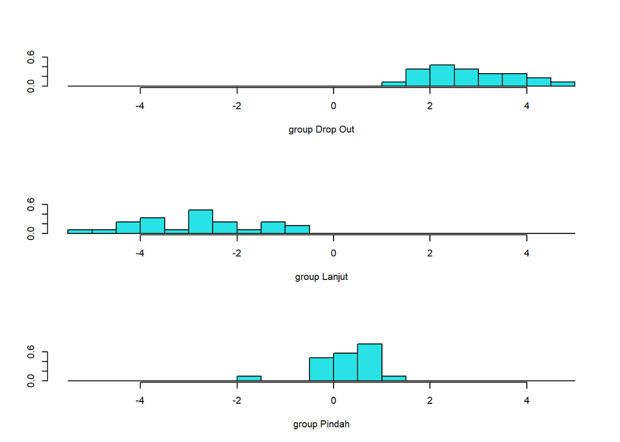

  ```r
  # fungsi pertama
  ldahist(predict_lda2$x[,1], g = ipk_train$Status)
  ```

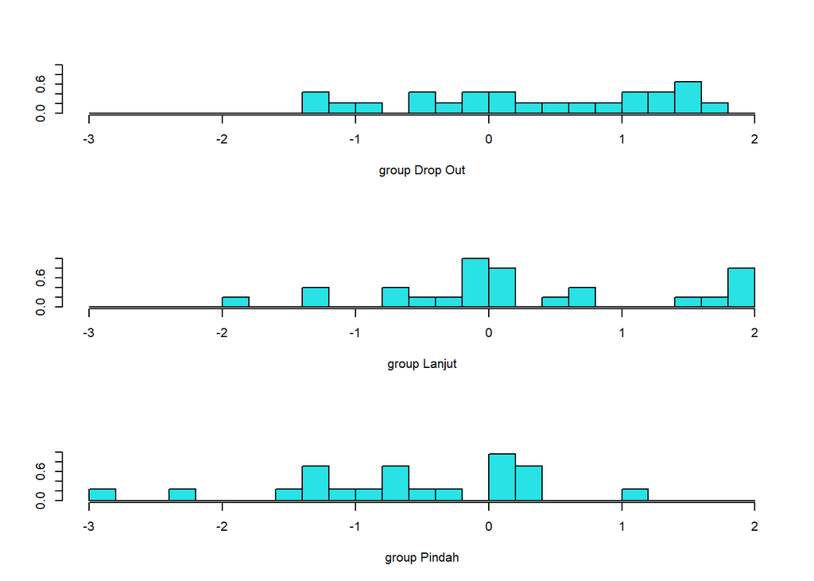

  ```r
  # fungsi kedua
  ldahist(predict_lda2$x[,2], g = ipk_train$Status)
  ```

  Selanjutnya pada fungsi diskriminan kedua, diperoleh bahwa fungsi diskriminan kedua belum cukup baik untuk mengklasifikasikan ketiga status mahasiswa terlihat dari irisannya yang besar.
- Evaluasi model LDA & QDA dengan data latih menggunakan histogram

  ```r
  # LDA
  table(ipk_train$Status, predict_lda2$class)
  ```

  ```
  ##
  ##            Drop Out Lanjut Pindah
  ##   Drop Out       22      0      1
  ##   Lanjut          0     23      2
  ##   Pindah          0      0     21
  ```

  ```r
  # tingkat kesalahan klasifikasi
  sum(ipk_train$Status != predict_lda2$class)/length(predict_lda2$class)
  ```

  ```
  ## [1] 0.04347826
  ```

  Berdasarkan data latih, diperoleh bahwa terdapat satu mahasiswa yang *Drop Out* namun diklasifikasikan *Pindah* berdasarkan model LDA, serta dua mahasiswa yang *Lanjut* namun diklasifikasikan *Pindah*. Selain itu, tidak ada mahasiswa yang *Drop Out* namun salah diklasifikasikan *Lanjut* pada model diskriminan ini, karena terlihat dari fungsi diskriminan pertamanya yang sangat baik dalam mengklasifikasikan dua kelas tersebut. Selanjutnya, dari tiga mahasiswa yang salah diklasifikasikan, diperoleh bahwa tingkat kesalahan klasifikasi oleh model LDA pada data latih ini sebesar 4.35%.

  ```r
  # QDA
  table(ipk_train$Status, predict_qda2$class)
  ```

  ```
  ##
  ##            Drop Out Lanjut Pindah
  ##   Drop Out       22      0      1
  ##   Lanjut          0     24      1
  ##   Pindah          0      1     20
  ```

  ```r
  # tingkat kesalahan klasifikasi
  sum(ipk_train$Status != predict_qda2$class)/length(predict_qda2$class)
  ```

  ```
  ## [1] 0.04347826
  ```

  Berdasarkan data latih pula, diperoleh bahwa terdapat tiga mahasiswa yang salah diklasifikasikan sehingga besaran tingkat kesalahan klasifikasinya juga sama besar. Di mana, masing-masing satu mahasiswa diklasifikasikan salah sebagai berikut: mahasiswa *Pindah* diklasifikasikan *Lanjut*, dan sebaliknya, serta mahasiswa *Drop Out* diklasifikasikan *Pindah*.

#### Evaluasi model dengan data uji

```r
predict_lda_test2 <- predict(ipk_lda, newdata = ipk_test)
predict_qda_test2 <- predict(ipk_qda, newdata = ipk_test)
```

Berdasarkan data uji, diperoleh bahwa terdapat satu mahasiswa yang *Drop Out* namun diklasifikasikan *Pindah* berdasarkan model LDA, serta dua mahasiswa yang *Lanjut* namun diklasifikasikan *Pindah*. Selain itu, tidak ada mahasiswa yang *Drop Out* namun salah diklasifikasikan *Lanjut* pada model diskriminan ini, karena terlihat dari fungsi diskriminan pertamanya yang sangat baik dalam mengklasifikasikan dua kelas tersebut. Selanjutnya, dari tiga mahasiswa yang salah diklasifikasikan, diperoleh bahwa tingkat kesalahan klasifikasi oleh model LDA pada data uji ini sebesar 18.75%.

Sedangkan berdasarkan data uji pula, diperoleh tidak ada yang salah diklasifikasikan dengan model QDA. Terlihat bahwa model QDA lebih baik dalam memprediksi kelas/status akademik mahasiswa.

Untuk melihat amatan yang salah diprediksi, dilakukan dengan code sebagai berikut:

```r
# LDA
table(ipk_test$Status, predict_lda_test2$class)
```

```
##
##            Drop Out Lanjut Pindah
##   Drop Out        4      0      1
##   Lanjut          0      4      2
##   Pindah          0      0      5
```

```r
# tingkat kesalahan klasifikasi
sum(ipk_test$Status != predict_lda_test2$class)/length(predict_lda_test2$class)
```

```
## [1] 0.1875
```

```r
# melihat amatan yang salah diklasifikasikan
cbind(ipk_test, Status_pred = predict_lda_test2$class)[ipk_test$Status != predict_lda_test2$class,]
```

```
##     IPK Skor.tes   Status Status_pred
## 24 3.40      431   Lanjut      Pindah
## 31 3.24      467   Lanjut      Pindah
## 58 2.85      381 Drop Out      Pindah
```

```r
# QDA
table(ipk_test$Status, predict_qda_test2$class)
```

```
##
##            Drop Out Lanjut Pindah
##   Drop Out        5      0      0
##   Lanjut          0      6      0
##   Pindah          0      0      5
```

```r
# tingkat kesalahan klasifikasi
sum(ipk_test$Status != predict_qda_test2$class)/length(predict_qda_test2$class)
```

```
## [1] 0
```

# Pertemuan 11 Analisis Biplot

## Langkah-Langkah

Langkah-langkah melakukan analisis biplot secara manual adalah sebagai berikut:

1. Siapkan data dalam bentuk matriks **X**, di mana matriks **X** adalah matriks data yang telah dikoreksi terhadap rata-ratanya
2. Hitung **X’X** kemudian cari akar cirinya, $\lambda_i$, dan vektor ciri yang bersesuaian
3. Hitung matriks **U**, **L**, dan **A**
4. Cari nilai **G** dan **H**
5. Tentukan G* (kolom ke-1 dan ke-2 dari matriks **G**) sebagai koordinat objek dan H* (kolom ke-1 dan ke-2 matriks **H**) sebagai koordinat peubah
6. Gambar biplot dengan koordinat G* dan H*
7. Hitung ukuran kebaikan biplot (besar keragaman yang dapat dijelaskan oleh biplot yang terbentuk)

## Studi Kasus 1

Tabel berikut memberikan data beberapa universitas dengan beberapa peubah yang digunakan untuk perbandingan/perangkingan universitas, di mana terdiri dari:

- `SAT` : rata-rata nilai SAT mahasiswa baru
- `Top10` : persentase mahasiswa baru yang merupakan 10% teratas di SMA asal
- `Accept` : persentase pelamar yang diterima
- `SFRatio` : rasio fakultas dan mahasiswa
- `Expenses` : biaya pendidikan tahunan (estimasi), dan
- `Grad` : rasio kelulusan (%)

### Menyiapkan data

```r
univs <- read.table(header = T, text =
"
University;SAT;Top10;Accept;SFRatio;Expenses;Grad
Harvard;14;91;14;11;39.525;97
Princeton;13.75;91;14;8;30.22;95
Yale;13.75;95;19;11;43.514;96
Stanford;13.6;90;20;12;36.45;93
MIT;13.8;94;30;10;34.87;91
Duke;13.15;90;30;12;31.585;95
Dartmouth;13.4;89;23;10;32.162;95
", sep=";")
head(univs)
```

```
##   University   SAT Top10 Accept SFRatio Expenses Grad
## 1    Harvard 14.00    91     14      11   39.525   97
## 2  Princeton 13.75    91     14       8   30.220   95
## 3       Yale 13.75    95     19      11   43.514   96
## 4   Stanford 13.60    90     20      12   36.450   93
## 5        MIT 13.80    94     30      10   34.870   91
## 6       Duke 13.15    90     30      12   31.585   95
```

Agar nama-nama objek (universitas) menjadi nama bagi masing-masing baris, maka dilakukan sesuai kode berikut:

```r
rownames(univs) <- univs$University
univs_new <- univs[,-1] #hapus kolom nama universitas
head(univs_new)
```

```
##             SAT Top10 Accept SFRatio Expenses Grad
## Harvard   14.00    91     14      11   39.525   97
## Princeton 13.75    91     14       8   30.220   95
## Yale      13.75    95     19      11   43.514   96
## Stanford  13.60    90     20      12   36.450   93
## MIT       13.80    94     30      10   34.870   91
## Duke      13.15    90     30      12   31.585   95
```

Diperoleh ringkasan/deskripsi data sebagai berikut.

```r
summary(univs_new)
```

```
##       SAT            Top10           Accept         SFRatio
##  Min.   :13.15   Min.   :89.00   Min.   :14.00   Min.   : 8.00
##  1st Qu.:13.50   1st Qu.:90.00   1st Qu.:16.50   1st Qu.:10.00
##  Median :13.75   Median :91.00   Median :20.00   Median :11.00
##  Mean   :13.64   Mean   :91.43   Mean   :21.43   Mean   :10.57
##  3rd Qu.:13.78   3rd Qu.:92.50   3rd Qu.:26.50   3rd Qu.:11.50
##  Max.   :14.00   Max.   :95.00   Max.   :30.00   Max.   :12.00
##     Expenses          Grad
##  Min.   :30.22   Min.   :91.00
##  1st Qu.:31.87   1st Qu.:94.00
##  Median :34.87   Median :95.00
##  Mean   :35.48   Mean   :94.57
##  3rd Qu.:37.99   3rd Qu.:95.50
##  Max.   :43.51   Max.   :97.00
```

Dari hasil di atas, diperoleh statistik 5 serangkai dari masing-masing peubah yang menjelaskan universitas.

Kemudian dilakukan visualisasi data menggunakan boxplot sebagai berikut:

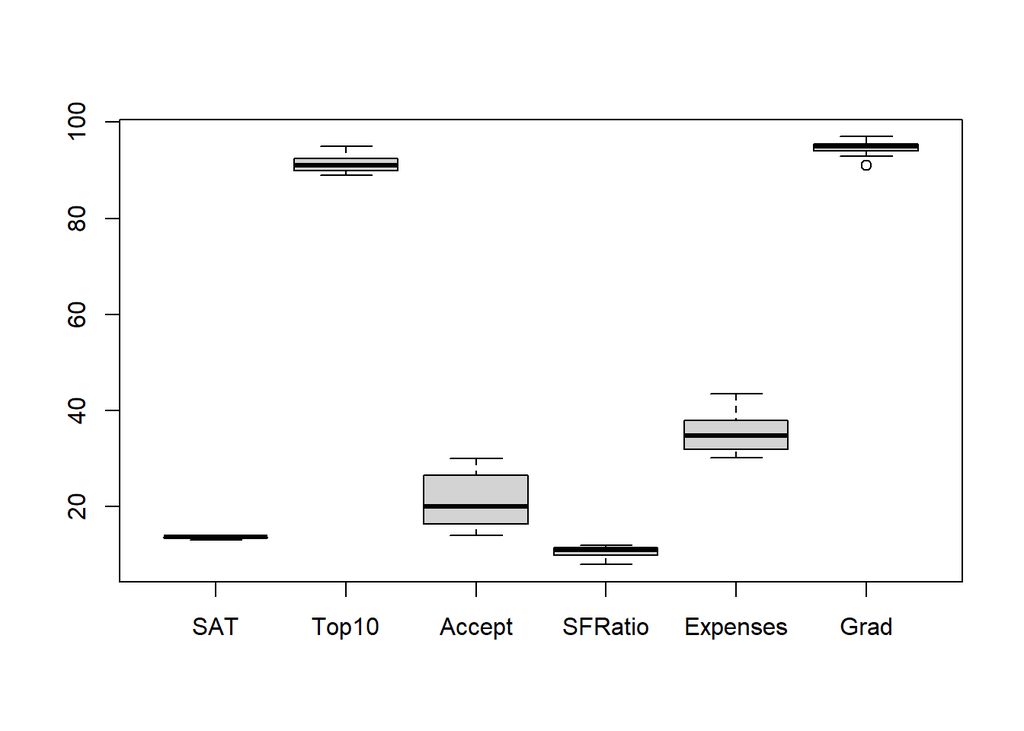

```r
boxplot(univs_new)
```

Boxplot digunakan untuk memeriksa keberadaan pencilan dalam suatu peubah. Terlihat dari plot di atas, bahwa peubah `Grad` memiliki pencilan bawah. Sedangkan 5 peubah lainnya tidak memiliki pencilan. Selanjutnya, dilakukan eksplorasi mengenai korelasi antar peubah dengan fungsi `corrplot()`.

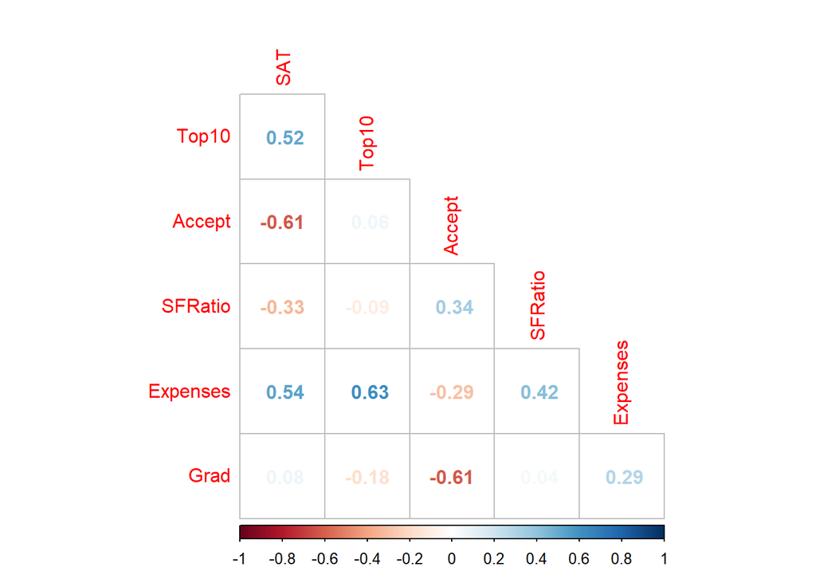

```r
library(corrplot)
corrplot(cor(univs_new), method = "number", is.cor = T, type = "lower", diag=F)
```

### Analisis biplot

Analisis ini menggunakan beberapa *package* antara lain:

- `FactoMineR` untuk membentuk fungsi komponen utama
- `factoextra` untuk membentuk grafik biplot

```r
library(FactoMineR)
library(factoextra)
```

1. Penskalaan/pengoreksian data

Sebelum melakukan analisis biplot, dilakukan pengoreksian data (matriks **X**) terhadap rataannya menggunakan fungsi `scale()`.

```r
df = scale(univs_new,scale = FALSE)
head(df)
```

```
##                   SAT      Top10    Accept    SFRatio   Expenses       Grad
## Harvard    0.36428571 -0.4285714 -7.428571  0.4285714  4.0498571  2.4285714
## Princeton  0.11428571 -0.4285714 -7.428571 -2.5714286 -5.2551429  0.4285714
## Yale       0.11428571  3.5714286 -2.428571  0.4285714  8.0388571  1.4285714
## Stanford  -0.03571429 -1.4285714 -1.428571  1.4285714  0.9748571 -1.5714286
## MIT        0.16428571  2.5714286  8.571429 -0.5714286 -0.6051429 -3.5714286
## Duke      -0.48571429 -1.4285714  8.571429  1.4285714 -3.8901429  0.4285714
```

2. Pembentukan fungsi komponen utama dan grafik biplot

Pembentukan fungsi komponen utama dilakukan dengan menggunakan fungsi `PCA()`

```r
df_pca = PCA(df, graph = F,scale.unit = F)
```

Kemudian dilakukan pembentukan grafik biplot dengan fungsi `fviz_pca_biplot()` yang membutuhkan argumen berupa fungsi komponen utama yang telah dibentuk.

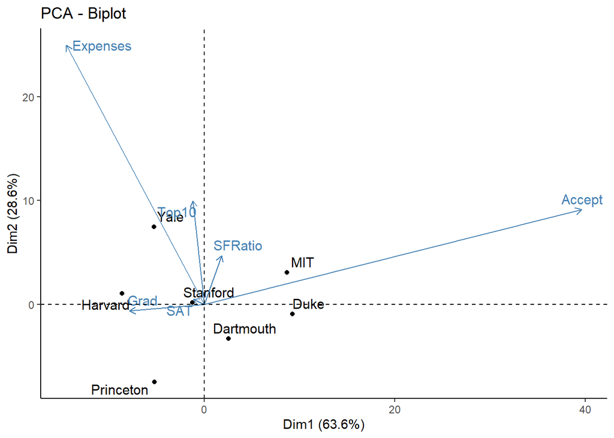

```r
fviz_pca_biplot(df_pca,repel = T) + theme_classic()
```

Silahkan lanjutkan dengan interpetasi yang lain.

Selanjutnya untuk mengevaluasi kebaikan dari biplot yang terbentuk, dilakukan dengan melihat persentase kumulatif keragaman yang diperoleh dari dua nilai eigen teratas (karena biplot yang terbentuk dua dimensi).

Kebaikan biplot dilihat berdasarkan `cumulative.variance.percent` dari nilai eigen kedua. (Informasi keragaman yang mampu dijelaskan oleh biplot adalah sebesar 92.28%. Artinya biplot mampu memberikan informasi dari 6 peubah untuk menilai posisi relatif 7 Universitas)

```r
eigen_values <- get_eigenvalue(df_pca)
eigen_values
```

```
##        eigenvalue variance.percent cumulative.variance.percent
## Dim.1 42.67114186      63.63352772                    63.63353
## Dim.2 19.20763975      28.64347715                    92.27700
## Dim.3  3.53817575       5.27632012                    97.55332
## Dim.4  1.45402436       2.16832022                    99.72165
## Dim.5  0.17303034       0.25803225                    99.97968
## Dim.6  0.01362782       0.02032254                   100.00000
```

Selain itu, dapat melihat presentase keragaman biplot dengan grafik plot scree dengan menggunakan `fviz_eig()` berikut.

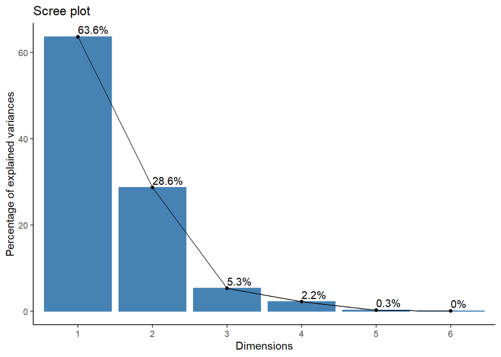

```r
fviz_eig(df_pca, addlabels = T) + theme_classic()
```

## Studi Kasus 2

Pertengahan tahun 2003 yang lalu Bank ”BR” melakukan evaluasi terhadap keuntungan yang mereka peroleh. Sebagai bank pemerintah dengan aset yang cukup besar, BR tidak memiliki keuntungan yang cukup tinggi dan bahkan cenderung mengalami penurunan keuntungan akibat menurunnya kuantitas dan kualitas nasabahnya. Managemen BR merekomendasikan pelaksanaan riset pasar terhadap persepsi masyarakat terhadap performa BR dan perbandinganya dengan performa bank-bank nasional lainnya. Dengan mengetahui posisi bank berdasarkan persepsi masyarakat ini, diharapkan dapat ditempuh langkah-langkah yang lebih baik.

Riset dilakukan dalam bentuk survei untuk mengumpulkan data persepsi masyarakat terhadap beberapa bank nasional. Survei tersebut melibatkan 2300 responden yang tersebar di 8 kota (Jakarta, Surabaya, Medan, Makasar, Balikpapan, Denpasar, Solo, dan Palembang). Setiap responden diminta untuk memberikan skor terhadap atribut/karakteristik berikut:

- Kualitas petugas bank dalam memberikan layanan
- Kualitas produk yang ditawarkan oleh bank
- Kualitas fasilitas kantor cabang
- Kualitas dan kuantitas fasilitas ATM
- Kualitas hadiah yang ditawarkan oleh bank
- Keamanan bertransaksi
- Kemudahan mencapai lokasi pelayanan bank

Penilaian dilakukan menggunakan skala 1, 2, …, 10. Nilai yang semakin besar menunjukkan kecenderungan yang positif terhadap atribut yang ditanyakan.

### Menyiapkan data

```r
bank <- read.table(header = T, text =
"
layanan;produk;cabang;ATM;hadiah;aman;lokasi
4.31;3.89;5.67;5.89;5.12;7.11;4.12
7.64;7.4;8.58;8.15;6.74;8.23;6.77
8.94;7.12;8.61;6.89;7.45;8.35;7.89
7.21;4.2;6.39;3.58;4.23;6.87;4.34
5.74;6.34;8.22;6.31;7.05;7.65;6.89
4.03;3.55;4.26;4.09;6.9;6.8;3.44
6.96;3.11;4.09;3.23;3.21;6.12;2.86
4.99;5;6.31;6.17;5.89;7.62;5.36
",
sep = ";")
rownames(bank) <- c("BR", "BC", "BMD", "NI", "BN", "BDN", "BMG", "BPM")
bank
```

```
##     layanan produk cabang  ATM hadiah aman lokasi
## BR     4.31   3.89   5.67 5.89   5.12 7.11   4.12
## BC     7.64   7.40   8.58 8.15   6.74 8.23   6.77
## BMD    8.94   7.12   8.61 6.89   7.45 8.35   7.89
## NI     7.21   4.20   6.39 3.58   4.23 6.87   4.34
## BN     5.74   6.34   8.22 6.31   7.05 7.65   6.89
## BDN    4.03   3.55   4.26 4.09   6.90 6.80   3.44
## BMG    6.96   3.11   4.09 3.23   3.21 6.12   2.86
## BPM    4.99   5.00   6.31 6.17   5.89 7.62   5.36
```

### Analisis biplot

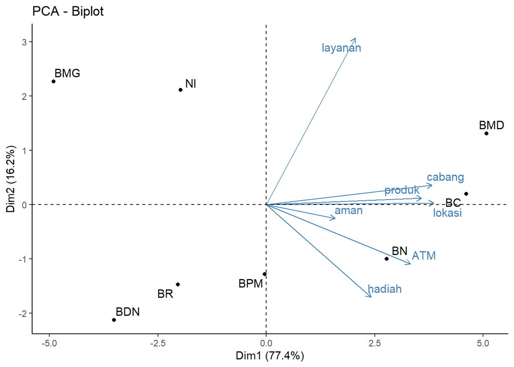

```r
bank2 = scale(bank,scale = FALSE)
bank_pca = PCA(bank2, graph = F, scale.unit=F)
fviz_pca_biplot(bank_pca,repel = T) + theme_classic()
```

(Interpretasi lain dapat ditambahkan sendiri)

Kemudian dilakukan evaluasi hasil biplot yang terbentuk sebagai berikut:

```r
eigen_values2 <- get_eigenvalue(bank_pca)
eigen_values2
```

```
##         eigenvalue variance.percent cumulative.variance.percent
## Dim.1 12.396059243      77.40058498                    77.40058
## Dim.2  2.589099919      16.16625448                    93.56684
## Dim.3  0.631795008       3.94490719                    97.51175
## Dim.4  0.298870837       1.86613965                    99.37789
## Dim.5  0.062252748       0.38870410                    99.76659
## Dim.6  0.027808207       0.17363353                    99.94022
## Dim.7  0.009573412       0.05977607                   100.00000
```

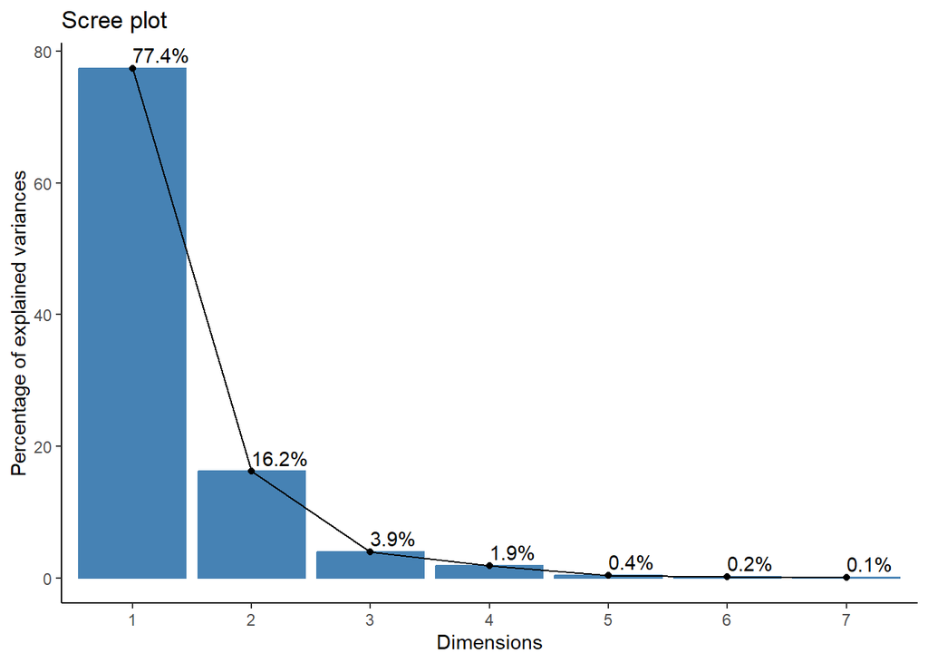

```r
fviz_eig(bank_pca, addlabels = T) + theme_classic()
```

Informasi keragaman yang mampu dijelaskan oleh biplot adalah sebesar 93.57%. Artinya biplot mampu memberikan informasi dari 7 peubah untuk menilai posisi relatif 8 bank berdasarkan kualitasnya.

# Pertemuan 12 Analisis Korespodensi

## Langkah-Langkah

Beberapa langkah yang dilakukan untuk membentuk plot korespondensi antara lain:

1. Siapkan data, kemudian bentuk tabel kontingensi.
2. Berdasarkan tabel kontingensi, bentuk tabel korespondensi dengan cara membagi masing-masing nilai dalam tabel kontingensi dengan n (banyak amatan).
3. Bentuk vektor baris, vektor kolom, matriks baris, dan matriks kolom berdasarkan tabel korespondensi yang telah dibuat.
4. Lakukan analisis profil baris dengan membagi proporsi/frekuensi masing-masing elemen dengan total proporsi/frekuensi masing-masing baris.
5. Lakukan analisis profil kolom dengan membagi proporsi/frekuensi masing-masing elemen dengan total proporsi/frekuensi masing-masing kolom.
6. Tentukan koordinat profil baris dan kolom dengan menggunakan Generalized SVD.
7. Bentuk plot korespondensi berdasarkan koordinat yang diperoleh.

## Studi Kasus 1 - Data Stasiun TV

- Suatu survei dilakukan untuk mengetahui stasiun TV favorit menurut pemirsa dengan kelompok usia tertentu.
- Ada 5 stasiun TV yang menjadi pilihan di dalam survei, yaitu **MetroTV**, **Indosiar**, **NETTV**, **TransTV**, dan **RCTI**.
- Sementara respondennya, dikelompokkan dalam 4 kelompok umur, yaitu **> 50 th**, **40-50 th**, **20-39 th**, dan **10-19 th**.

### Import Data

```r
stasiun_tv <- read.csv("https://raw.githubusercontent.com/nurkhamidah/dat/main/stasiun_tv.csv", sep = ";")
stasiun_tv
```

```
##        Usia Stasiun.TV Jumlah
## 1   > 50 th    MetroTV    326
## 2  40-50 th    MetroTV    688
## 3  20-39 th    MetroTV    343
## 4  10-19 th    MetroTV     98
## 5   > 50 th   Indosiar     38
## 6  40-50 th   Indosiar    116
## 7  20-39 th   Indosiar     84
## 8  10-19 th   Indosiar     48
## 9   > 50 th      NETTV    241
## 10 40-50 th      NETTV    584
## 11 20-39 th      NETTV    909
## 12 10-19 th      NETTV    403
## 13  > 50 th    TransTV    110
## 14 40-50 th    TransTV    188
## 15 20-39 th    TransTV    412
## 16 10-19 th    TransTV    681
## 17  > 50 th       RCTI      3
## 18 40-50 th       RCTI      4
## 19 20-39 th       RCTI     26
## 20 10-19 th       RCTI     85
```

### Penyelesaian Manual

1. **Tabel Kontingensi**

   Dari data yang terbentuk, dapat kita bentuk tabel kontingensi sebagai berikut:

   ```r
   stasiun_tv$Usia <- factor(stasiun_tv$Usia, levels=c("> 50 th", "40-50 th",
                                                       "20-39 th", "10-19 th"))
   stasiun_tv$Stasiun.TV <- factor(stasiun_tv$Stasiun.TV,
                                   levels=c("MetroTV", "Indosiar",
                                            "NETTV","TransTV","RCTI"))
   table_count <- xtabs(Jumlah ~ Usia + Stasiun.TV, data = stasiun_tv)
   table_count
   ```

   ```
   ##           Stasiun.TV
   ## Usia       MetroTV Indosiar NETTV TransTV RCTI
   ##   > 50 th      326       38   241     110    3
   ##   40-50 th     688      116   584     188    4
   ##   20-39 th     343       84   909     412   26
   ##   10-19 th      98       48   403     681   85
   ```

2. **Tabel Korespondensi**

   ```r
   n <- sum(table_count)
   table_coresp <- table_count/n
   table_coresp
   ```

   ```
   ##           Stasiun.TV
   ## Usia            MetroTV     Indosiar        NETTV      TransTV         RCTI
   ##   > 50 th  0.0605160572 0.0070540189 0.0447373306 0.0204195285 0.0005568962
   ##   40-50 th 0.1277148691 0.0215333210 0.1084091331 0.0348988305 0.0007425283
   ##   20-39 th 0.0636718025 0.0155930945 0.1687395582 0.0764804158 0.0048264340
   ##   10-19 th 0.0181919436 0.0089103397 0.0748097271 0.1264154446 0.0157787266
   ```

3. **Vektor kolom dan vektor baris**

   Berdasarkan matriks korespondensi yang terbentuk, diperoleh vektor kolom dan vektor baris berikut:

   ```r
   c <- colSums(table_coresp)
   c
   ```

   ```
   ##    MetroTV   Indosiar      NETTV    TransTV       RCTI
   ## 0.27009467 0.05309077 0.39669575 0.25821422 0.02190459
   ```

   ```r
   r <- rowSums(table_coresp)
   r
   ```

   ```
   ##   > 50 th  40-50 th  20-39 th  10-19 th
   ## 0.1332838 0.2932987 0.3293113 0.2441062
   ```

4. **Matriks kolom dan matriks baris**

   ```r
   Dc <- diag(c)
   Dc
   ```

   ```
   ##           [,1]       [,2]      [,3]      [,4]       [,5]
   ## [1,] 0.2700947 0.00000000 0.0000000 0.0000000 0.00000000
   ## [2,] 0.0000000 0.05309077 0.0000000 0.0000000 0.00000000
   ## [3,] 0.0000000 0.00000000 0.3966957 0.0000000 0.00000000
   ## [4,] 0.0000000 0.00000000 0.0000000 0.2582142 0.00000000
   ## [5,] 0.0000000 0.00000000 0.0000000 0.0000000 0.02190459
   ```

   ```r
   Dr <- diag(r)
   Dr
   ```

   ```
   ##           [,1]      [,2]      [,3]      [,4]
   ## [1,] 0.1332838 0.0000000 0.0000000 0.0000000
   ## [2,] 0.0000000 0.2932987 0.0000000 0.0000000
   ## [3,] 0.0000000 0.0000000 0.3293113 0.0000000
   ## [4,] 0.0000000 0.0000000 0.0000000 0.2441062
   ```

5. **Analisis profil baris**

   Profil baris diperoleh dengan:

   $$R = Dr^{-1}P$$

   ```r
   R <- solve(Dr)%*%table_coresp
   rownames(R) <- rownames(table_coresp)
   R
   ```

   ```
   ##           Stasiun.TV
   ##               MetroTV   Indosiar     NETTV   TransTV        RCTI
   ##   > 50 th  0.45403900 0.05292479 0.3356546 0.1532033 0.004178273
   ##   40-50 th 0.43544304 0.07341772 0.3696203 0.1189873 0.002531646
   ##   20-39 th 0.19334837 0.04735062 0.5124014 0.2322435 0.014656144
   ##   10-19 th 0.07452471 0.03650190 0.3064639 0.5178707 0.064638783
   ```

   - Pada kolom MetroTV, dapat dilihat bahwa baris usia >50 tahun mempunyai nilai tertinggi (0.454). Hal ini menunjukkan bahwa stasiun METRO TV menjadi stasiun TV favorit pemirsa yang berusia > 50 tahun.
   - Pada kolom Indosiar, dapat dilihat bahwa pemirsa dengan rentang usia 40-50 tahun memiliki nilai tertinggi (0.0734). Hal ini menunjukkan bahwa stasiun Indosiar menjadi stasiun TV favorit pemirsa yang berusia 40- 50 tahun.
   - Pada kolom NETTV, dapat dilihat bahwa baris usia 20-39 tahun memiliki nilai tertingggi (0.5124). Hal ini menunjukkan bahwa statiun NETTV menjadi stasiun TV favorit untuk pemirsa pada rentang usia 20-39 tahun.
   - Pada kolom TransTV dan RCTI, dapat dilihat bahwa usia 10-19 tahun memiliki nilai tertinggi (0.0646 dan 0.5179). Hal ini menunjukkan bahwa kedua stasiun televisi ini menjadi stasiun TV favorit pemirsa pada rentang usia 10-19 tahun.

   Kemudian diperoleh nilai massa setiap kolom sebagai berikut:

   ```r
   mass_c <- colSums(R)
   mass_c
   ```

   ```
   ##    MetroTV   Indosiar      NETTV    TransTV       RCTI
   ## 1.15735512 0.21019503 1.52414008 1.02230492 0.08600485
   ```

   Nilai massa terbesar adalah 1.52414 terdapat pada kolom stasiun televisi NETTV, masih sama dengan modus amatan yang kita peroleh pada data awal.
6. **Analisis profil kolom**

   Profil baris diperoleh dengan:

   $$C = P Dc^{-1}$$

   ```r
   C <- table_coresp %*% solve(Dc)
   colnames(C) <- colnames(table_coresp)
   C
   ```

   ```
   ##
   ## Usia          MetroTV  Indosiar     NETTV   TransTV       RCTI
   ##   > 50 th  0.22405498 0.1328671 0.1127749 0.0790798 0.02542373
   ##   40-50 th 0.47285223 0.4055944 0.2732803 0.1351546 0.03389831
   ##   20-39 th 0.23573883 0.2937063 0.4253627 0.2961898 0.22033898
   ##   10-19 th 0.06735395 0.1678322 0.1885821 0.4895758 0.72033898
   ```

   - Usia pada kategori > 50 tahun dan 40-50 tahun, mempunyai massa terbesar pada stasiun televisi MetroTV yaitu 0.2240 dan 0.4729. Hal ini menunjukkan bahwa usia terbanyak yang sering menonton METRO TV adalah pemirsa pada usia > 50 tahun dan 40-50 tahun.
   - Usia pada kategori 20-39 tahun, mempunyai massa terbesar pada stasiun televisi NETTV yaitu 0.4254. Hal ini menunjukkan bahwa usia terbanyak yang sering menonton NET TV adalah pemirsa pada usia 20-39 tahun.
   - Usia pada kategori 10-19 tahun, mempunyai massa terbesar pada stasiun televisi RCTI yaitu 0.7203. Hal ini menunjukkan bahwa usia terbanyak yaang sering menonton RCTI adalah pemirsa pada usia 10-19 tahun.

   Kemudian diperoleh nilai massa setiap baris sebagai berikut:

   ```r
   mass_r <- rowSums(C)
   mass_r
   ```

   ```
   ##   > 50 th  40-50 th  20-39 th  10-19 th
   ## 0.5742006 1.3207798 1.4713366 1.6336831
   ```

   Nilai massa terbesar adalah 1.633683 terdapat pada usia kategori 10-19 tahun, jadi berbeda dengan modus amatan yang diperoleh pada data awal yaitu pada kategori usia 20-39 tahun.
7. **Menentukan koordinat profil baris dan kolom**

   Koordinat baris dan kolom yang ditentukan menggunakan GSVD melalui matriks:

   $$P-rc'$$

   ```r
   Prc <- table_coresp - r%*%t(c)
   Prc
   ```

   ```
   ##           Stasiun.TV
   ## Usia             MetroTV      Indosiar         NETTV       TransTV
   ##   > 50 th   2.451680e-02 -2.212285e-05 -8.135799e-03 -1.399625e-02
   ##   40-50 th  4.849646e-02  5.961867e-03 -7.941207e-03 -4.083506e-02
   ##   20-39 th -2.527343e-02 -1.890298e-03  3.810316e-02 -8.552446e-03
   ##   10-19 th -4.773984e-02 -4.049446e-03 -2.202616e-02  6.338376e-02
   ##           Stasiun.TV
   ## Usia                RCTI
   ##   > 50 th  -2.362631e-03
   ##   40-50 th -5.682058e-03
   ##   20-39 th -2.386994e-03
   ##   10-19 th  1.043168e-02
   ```

   Kemudian matriks Z diperoleh melalui:

   ```r
   Z <- diag(1/sqrt(diag(Dr)))%*%Prc%*%diag(1/sqrt(diag(Dc)))
   Z
   ```

   ```
   ##            [,1]          [,2]        [,3]        [,4]        [,5]
   ## [1,]  0.1292162 -0.0002629922 -0.03538203 -0.07544543 -0.04372599
   ## [2,]  0.1723046  0.0477768696 -0.02328106 -0.14838434 -0.07088969
   ## [3,] -0.0847428 -0.0142960921  0.10542144 -0.02932898 -0.02810479
   ## [4,] -0.1859232 -0.0355710546 -0.07078163  0.25246345  0.14265843
   ```

   ```r
   Du <- diag(sqrt(eigen(Z %*% t(Z))$values))[1:2,1:2]
   Du
   ```

   ```
   ##           [,1]      [,2]
   ## [1,] 0.4463684 0.0000000
   ## [2,] 0.0000000 0.1734554
   ```

   Kemudian dari matriks **Z** yang sudah diperoleh, dicari matriks **U** (vektor ciri dari **ZZ’**) dan matriks **V** (vektor ciri dari matriks **Z’Z**).

   ```r
   library(factoextra)
   U <- eigen(Z %*% t(Z))$vectors
   U
   ```

   ```
   ##             [,1]       [,2]        [,3]      [,4]
   ## [1,] -0.32740153  0.3481491  0.79894718 0.3650806
   ## [2,] -0.53470247  0.2762034 -0.58694655 0.5415706
   ## [3,]  0.04321499 -0.8105596  0.10869354 0.5738565
   ## [4,]  0.77783929  0.3814407 -0.07323162 0.4940710
   ```

   ```r
   A <- (sqrt(Dr) %*% U)[,1:2]
   A
   ```

   ```
   ##            [,1]       [,2]
   ## [1,] -0.1195279  0.1271025
   ## [2,] -0.2895791  0.1495836
   ## [3,]  0.0247992 -0.4651449
   ## [4,]  0.3843079  0.1884588
   ```

   ```r
   V <- eigen(t(Z) %*% Z)$vectors
   V
   ```

   ```
   ##             [,1]       [,2]        [,3]       [,4]        [,5]
   ## [1,] -0.63337328  0.5208721  0.22198126 -0.5274987  0.00000000
   ## [2,] -0.12040878  0.0641327 -0.92784507 -0.1825513 -0.29524104
   ## [3,] -0.05929716 -0.7563782  0.06953154 -0.6464176  0.04105527
   ## [4,]  0.67018848  0.3045289  0.17534533 -0.4302105 -0.49222197
   ## [5,]  0.36286535  0.2444040 -0.23291035 -0.2923755  0.81784150
   ```

   ```r
   B <- (sqrt(Dc) %*% V)[,1:2]
   B
   ```

   ```
   ##             [,1]        [,2]
   ## [1,] -0.32916810  0.27070055
   ## [2,] -0.02774391  0.01477709
   ## [3,] -0.03734760 -0.47639565
   ## [4,]  0.34055482  0.15474573
   ## [5,]  0.05370479  0.03617228
   ```

   **Koordinat baris**

   ```r
   rows <- solve(Dr)%*%A%*%Du
   rows
   ```

   ```
   ##             [,1]        [,2]
   ## [1,] -0.40029985  0.16541100
   ## [2,] -0.44070764  0.08846303
   ## [3,]  0.03361434 -0.24500190
   ## [4,]  0.70273880  0.13391383
   ```

   **Koordinat kolom**

   ```r
   cols <- solve(Dc)%*%B%*%Du
   cols
   ```

   ```
   ##             [,1]        [,2]
   ## [1,] -0.54399533  0.17384449
   ## [2,] -0.23326097  0.04827895
   ## [3,] -0.04202412 -0.20830421
   ## [4,]  0.58870853  0.10395044
   ## [5,]  1.09438828  0.28643670
   ```

8. **visualisasi berdasarkan koordinat profil baris dan kolom**

```r
row_df <- data.frame(rows)
col_df <- data.frame(cols)
colnames(row_df) <- c("Dim.1", "Dim.2")
rownames(row_df) <- rownames(table_count)
colnames(col_df) <- c("Dim.1", "Dim.2")
rownames(col_df) <- colnames(table_count)
row_df["Var"] <- "Usia"
row_df["Size"] <- 2
col_df["Var"] <- "Stasiun TV"
col_df["Size"] <- 2
ca.plot.df <- rbind(col_df, row_df)
ca.plot.df["Label"] <- rownames(ca.plot.df)
ca.plot.df
```

```
##                Dim.1       Dim.2        Var Size    Label
## MetroTV  -0.54399533  0.17384449 Stasiun TV    2  MetroTV
## Indosiar -0.23326097  0.04827895 Stasiun TV    2 Indosiar
## NETTV    -0.04202412 -0.20830421 Stasiun TV    2    NETTV
## TransTV   0.58870853  0.10395044 Stasiun TV    2  TransTV
## RCTI      1.09438828  0.28643670 Stasiun TV    2     RCTI
## > 50 th  -0.40029985  0.16541100       Usia    2  > 50 th
## 40-50 th -0.44070764  0.08846303       Usia    2 40-50 th
## 20-39 th  0.03361434 -0.24500190       Usia    2 20-39 th
## 10-19 th  0.70273880  0.13391383       Usia    2 10-19 th
```

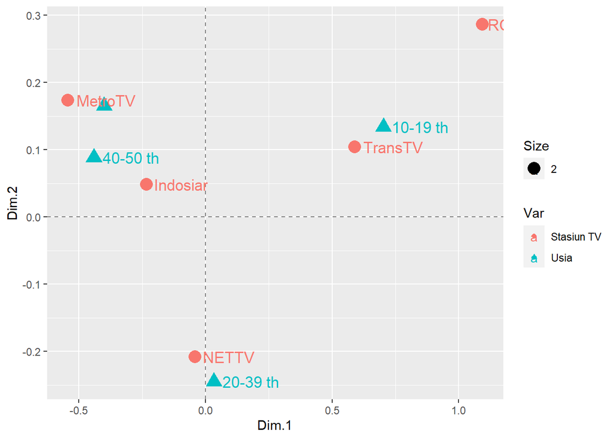

```r
library(ggplot2)
p <- ggplot(ca.plot.df, aes(x = Dim.1, y = Dim.2,
                       col = Var, shape = Var,
                       label = Label, size = Size)) +
  geom_vline(xintercept = 0, lty = "dashed", alpha = .5) +
  geom_hline(yintercept = 0, lty = "dashed", alpha = .5) +
  geom_point() + geom_text(check_overlap = T, hjust=-0.15)

plot(p)
```

### Penyelesaian dengan R

Untuk menyelesaikan analisis korespondensi dengan R, data yang digunakan adalah data yang telah direpresentasikan pada tabel kontingensi, sebagaimana yang tersimpan pada objek `table_count`. *Package* yang digunakan adalah `FactoMineR` dengan fungsi `CA()`, serta visualisasi menggunakan `factoextra`.

```r
library(factoextra)
library(FactoMineR)
table_count
```

```
##           Stasiun.TV
## Usia       MetroTV Indosiar NETTV TransTV RCTI
##   > 50 th      326       38   241     110    3
##   40-50 th     688      116   584     188    4
##   20-39 th     343       84   909     412   26
##   10-19 th      98       48   403     681   85
```

### Eksplorasi Data

Coba kita lakukan visualisasi dari tabel kontingensi yang terbentuk.

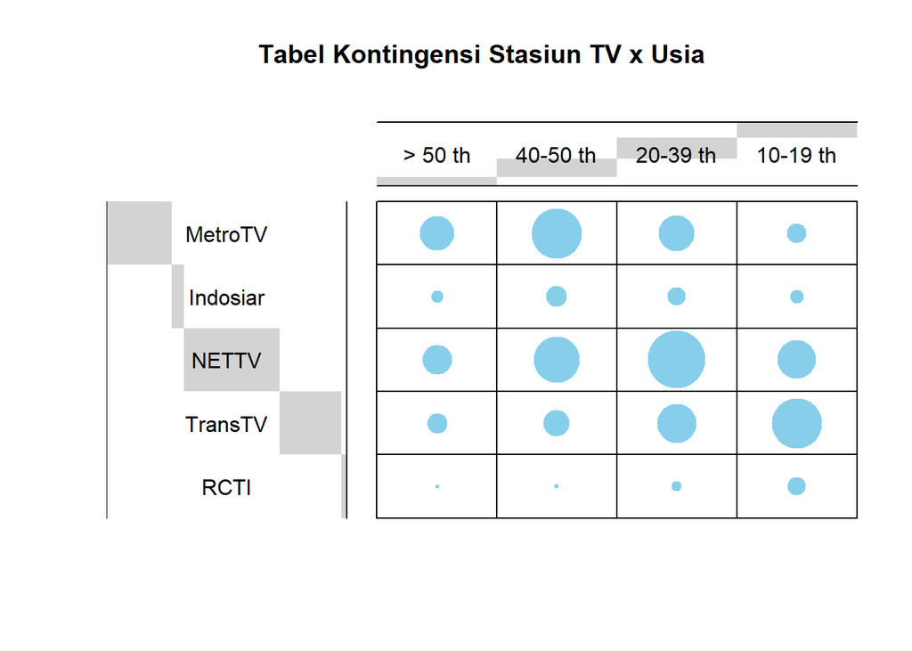

```r
# install.packages("gplots") # run ini jika package belum terinstall
library(gplots)
balloonplot(table_count, main ="Tabel Kontingensi Stasiun TV x Usia", xlab ="", ylab="", label = FALSE, show.margins = FALSE)
```

Di mana semakin besar lingkaran menunjukkan semakin besar pula nilai yang direpresentasikan.

```r
chisq <- chisq.test(table_count)
chisq
```

```
##
##  Pearson's Chi-squared test
##
## data:  table_count
## X-squared = 1240, df = 12, p-value < 2.2e-16
```

Diperoleh dari hasil uji Khi-kuadrat, bahwa kedua peubah (stasiun TV dan rentang usia) secara signifikan saling terkait.

### Membentuk model *Correspondence Analysis*

```r
model_tv <- CA(table_count, graph = F)
```

Untuk melihat objek/informasi apa saja yang terdapat dalam model, lakukan:

```r
print(model_tv)
```

```
## **Results of the Correspondence Analysis (CA)**
## The row variable has  4  categories; the column variable has 5 categories
## The chi square of independence between the two variables is equal to 1240.039 (p-value =  4.123993e-258 ).
## *The results are available in the following objects:
##
##    name              description
## 1  "$eig"            "eigenvalues"
## 2  "$col"            "results for the columns"
## 3  "$col$coord"      "coord. for the columns"
## 4  "$col$cos2"       "cos2 for the columns"
## 5  "$col$contrib"    "contributions of the columns"
## 6  "$row"            "results for the rows"
## 7  "$row$coord"      "coord. for the rows"
## 8  "$row$cos2"       "cos2 for the rows"
## 9  "$row$contrib"    "contributions of the rows"
## 10 "$call"           "summary called parameters"
## 11 "$call$marge.col" "weights of the columns"
## 12 "$call$marge.row" "weights of the rows"
```

Dengan menggunakan *package* `factoextra`, kita dapat memperoleh banyak informasi melalui fungsi-fungsi berikut:

- `get_eigenvalue(model)`, mengekstraksi nilai akar ciri.
- `fviz_screeplot(model)`, melakukan visualisasi presentase keragaman yang diperoleh.
- `get_ca_row(model)`, `get_ca_col(model)`, melakukan analisis profil baris dan kolom.
- `fviz_ca_row(model)` `fviz_ca_col(model)`, melakukan visualisasi profil baris dan kolom.
- `fviz_ca_biplot(model)` untuk melakukan visualisasi keduanya.
1. **Akar/vektor ciri**

```r
eig.val <- get_eigenvalue(model_tv)
eig.val
```

```
##         eigenvalue variance.percent cumulative.variance.percent
## Dim.1 0.1992447520       86.5562709                    86.55627
## Dim.2 0.0300867741       13.0703516                    99.62662
## Dim.3 0.0008594814        0.3733775                   100.00000
```

2. **Presentase keragaman**

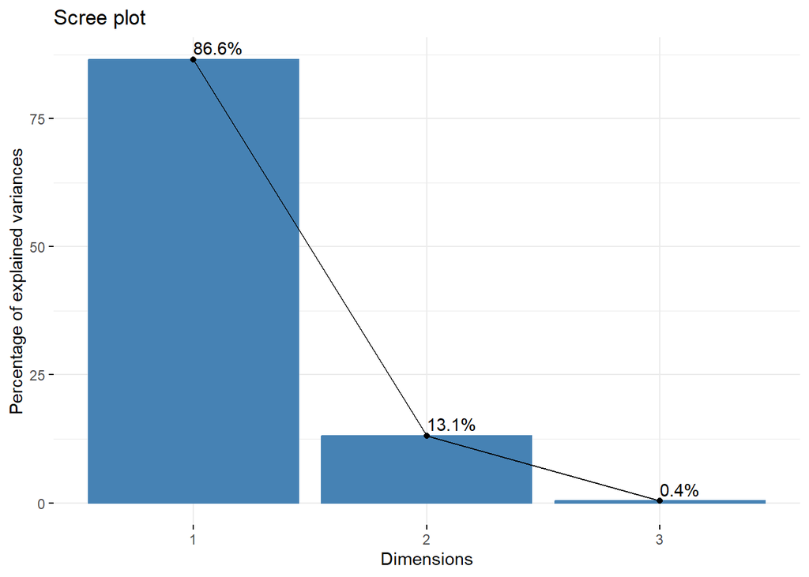

```r
fviz_screeplot(model_tv, addlabels = TRUE)
```

Dapat dilihat bahwa untuk mereduksi menjadi 2 dimensi saja, kita sudah mendapatkan 99.63% keragaman dalam data.

3. **Analisis dan visualisasi profil baris**

```r
row <- get_ca_row(model_tv)
row
```

```
## Correspondence Analysis - Results for rows
##  ===================================================
##   Name       Description
## 1 "$coord"   "Coordinates for the rows"
## 2 "$cos2"    "Cos2 for the rows"
## 3 "$contrib" "contributions of the rows"
## 4 "$inertia" "Inertia of the rows"
```

- Koordinat dari profil baris

```r
row$coord
```

```
##                Dim 1       Dim 2        Dim 3
## > 50 th  -0.40029985  0.16541100 -0.064157519
## 40-50 th -0.44070764  0.08846303  0.031773257
## 20-39 th  0.03361434 -0.24500190 -0.005552885
## 10-19 th  0.70273880  0.13391383  0.004345377
```

Untuk memetakan menjadi dua dimensi, maka hanya perlu melihat *Dim 1* dan *Dim 2* nya saja.

- Kontribusi keragaman profil baris

```r
row$contrib
```

```
##               Dim 1     Dim 2     Dim 3
## > 50 th  10.7191765 12.120781 63.831659
## 40-50 th 28.5906733  7.628833 34.450625
## 20-39 th  0.1867536 65.700687  1.181429
## 10-19 th 60.5033967 14.549698  0.536287
```

Profil baris yang berkontribusi paling banyak kepada *Dim 1* dan *Dim 2* adalah baris yang paling penting dalam menjelaskan keragaman data. Dalam hal ini, responden berusia 10-19 tahun dan 20-39 tahun dianggap sebagai responden yang menyumbang keragaman paling besar.

- Plot profil baris

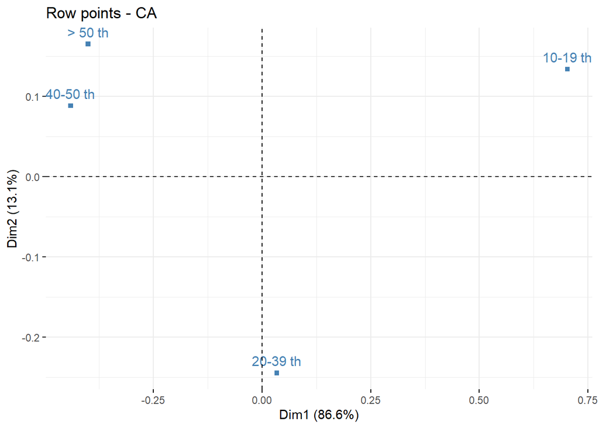

```r
fviz_ca_row(model_tv, col.row="steelblue", shape.row = 15)
```

– Baris dengan profil serupa dikelompokkan bersama.  
– Baris yang berkorelasi negatif diposisikan pada sisi yang saling berlawanan (kuadran berlawanan).

4. **Analisis dan visualisasi profil kolom**

```r
col <- get_ca_col(model_tv)
col
```

```
## Correspondence Analysis - Results for columns
##  ===================================================
##   Name       Description
## 1 "$coord"   "Coordinates for the columns"
## 2 "$cos2"    "Cos2 for the columns"
## 3 "$contrib" "contributions of the columns"
## 4 "$inertia" "Inertia of the columns"
```

- Koordinat dari profil kolom

```r
col$coord
```

```
##                Dim 1       Dim 2        Dim 3
## MetroTV  -0.54399533  0.17384449 -0.012522082
## Indosiar -0.23326097  0.04827895  0.118054940
## NETTV    -0.04202412 -0.20830421 -0.003236468
## TransTV   0.58870853  0.10395044 -0.010116315
## RCTI      1.09438828  0.28643670  0.046135954
```

Untuk memetakan menjadi dua dimensi, maka hanya perlu melihat *Dim 1* dan *Dim 2* nya saja.

- Kontribusi keragaman profil kolom

```r
col$contrib
```

```
##               Dim 1      Dim 2      Dim 3
## MetroTV  40.1161707 27.1307783  4.9275678
## Indosiar  1.4498275  0.4113003 86.0896470
## NETTV     0.3516154 57.2108003  0.4834635
## TransTV  44.9152601  9.2737881  3.0745985
## RCTI     13.1671264  5.9733330  5.4247232
```

Profil kolom yang berkontribusi paling banyak kepada *Dim 1* dan *Dim 2* adalah baris yang paling penting dalam menjelaskan keragaman data. Dalam hal ini, stasiun TV TransTV dan NETTV dianggap sebagai stasiun TV yang menyumbang keragaman paling besar.

- Plot profil kolom

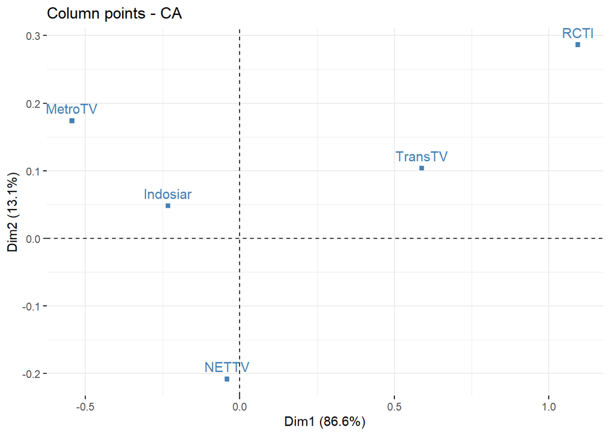

```r
fviz_ca_col(model_tv, col.col="steelblue", shape.col = 15)
```

5. **Pembentukan plot korespondensi**

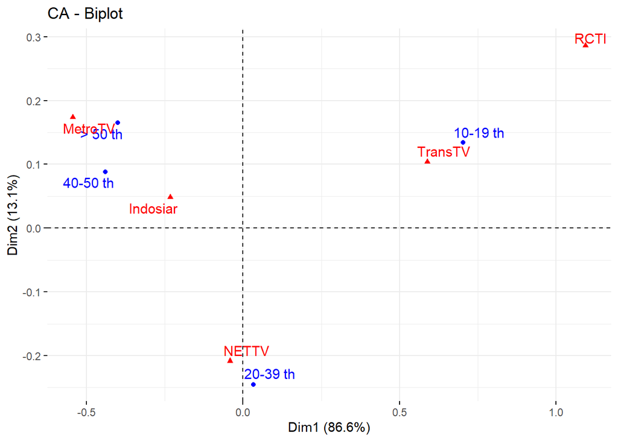

```r
fviz_ca_biplot(model_tv, repel = TRUE)
```

- Plot dalam gambar diatas, menunjukkan bagaimana korelasi antara stasiun TV favorit dengan berbagai kategori usia.
- Terlihat bahwa usia kategori 10-19 tahun berdekatan dengan stasiun televisi RCTI dan TransTV, artinya jelas bahwa pemirsa dengan rentang usia 10-19 tahun lebih sering menonton stasiun RCTI dan TransTV dibanding stasiun televisi lainnya.
- Kemudian pemirsa dengan kategori usia 20-39 tahun lebih sering menonton stasiun televisi NETTV.
- Terakhir, pemirsa dengan kategori usia 40-50 tahun dan > 50 tahun lebih sering menonton stasiun televisi Indosiar dan MetroTV dibanding stasiun televisi lainnya.

## Studi Kasus 2 - Data Kenyamanan Kerja x Pendapatan

Suatu data frekuensi tentang hubungan antara kenyamanan kerja dengan pendapatan yang disajikan pada tabel berikut :

1. **Import Data**

```r
df_kerja <- read.csv("https://raw.githubusercontent.com/nurkhamidah/dat/main/kenyamanan_pendapatan.csv", sep = ";")
rownames(df_kerja) <- df_kerja$X
df_kerja <- df_kerja[,-1]
df_kerja
```

```
##                Sangat.Tidak.Nyaman Kurang.Nyaman Biasa.Saja Nyaman
## < 25 jt/bln                     15            98         21     14
## 25 - 50 jt/bln                   4            49        125    250
## > 50 jt/bln                      1            13         81    300
```

2. **Eksplorasi dengan uji Khi-kuadrat**

H0 : variabel baris dan kolom dari tabel kontingensi adalah independen. H1 : variabel baris dan kolom dependen.

```r
chisq.test(df_kerja)
```

```
##
##  Pearson's Chi-squared test
##
## data:  df_kerja
## X-squared = 421.11, df = 6, p-value < 2.2e-16
```

Karena diperoleh *p-value* < 2.2e-16 maka H0 ditolak artinya terdapat hubungan yang erat antara pendapatan dan kenyamanan pekerjaan.

3. **Analisis korespondensi**

`library(ca)` adalah *package* R untuk mengaktifkan fungsi analisis korespondensi, jika belum tersedia `install.packages(ca)`

```r
# install.packages("ca")
library(ca)
fit <- ca(df_kerja)
summary(fit)
```

```
##
## Principal inertias (eigenvalues):
##
##  dim    value      %   cum%   scree plot
##  1      0.420978  97.1  97.1  ************************
##  2      0.012713   2.9 100.0  *
##         -------- -----
##  Total: 0.433691 100.0
##
##
## Rows:
##     name   mass  qlt  inr    k=1 cor ctr    k=2 cor ctr
## 1 | 25jt |  152 1000  795 | 1503 999 818 |  -50   1  30 |
## 2 | 2550 |  441 1000   37 | -143 570  21 |  125 430 538 |
## 3 | 50jt |  407 1000  169 | -408 925 161 | -116  75 432 |
##
## Columns:
##     name   mass  qlt  inr    k=1  cor ctr    k=2 cor ctr
## 1 | SnTN |   21 1000  132 | 1662  991 135 | -162   9  43 |
## 2 | KrnN |  165 1000  642 | 1300 1000 662 |  -16   0   3 |
## 3 | BsSj |  234 1000   31 | -132  304  10 |  199 696 731 |
## 4 | Nymn |  581 1000  195 | -375  966 194 |  -70  34 223 |
```

`fit=ca(data)` digunakan untuk melakukan analisis korespondensi. Diperoleh total keragaman yang dapat dijelaskan adalah sebesar 100%.

4. **Analisis profil baris dan kolom**

```r
n <- sum(df_kerja)
sum_row <- apply(df_kerja, 1, sum)
sum_row/n
```

```
##    < 25 jt/bln 25 - 50 jt/bln    > 50 jt/bln
##      0.1524202      0.4407827      0.4067971
```

```r
rows <- df_kerja/sum_row
rows
```

```
##                Sangat.Tidak.Nyaman Kurang.Nyaman Biasa.Saja     Nyaman
## < 25 jt/bln            0.101351351    0.66216216  0.1418919 0.09459459
## 25 - 50 jt/bln         0.009345794    0.11448598  0.2920561 0.58411215
## > 50 jt/bln            0.002531646    0.03291139  0.2050633 0.75949367
```

```r
sum_col <- apply(df_kerja, 2, sum)
sum_col/n
```

```
## Sangat.Tidak.Nyaman       Kurang.Nyaman          Biasa.Saja              Nyaman
##          0.02059732          0.16477858          0.23377961          0.58084449
```

```r
cols <- df_kerja/sum_col
cols
```

```
##                Sangat.Tidak.Nyaman Kurang.Nyaman Biasa.Saja    Nyaman
## < 25 jt/bln            0.750000000     0.1737589 0.09251101 0.0875000
## 25 - 50 jt/bln         0.025000000     2.4500000 0.22163121 1.1013216
## > 50 jt/bln            0.004405286     0.0812500 4.05000000 0.5319149
```

5. **Pembentukan plot korespondensi**

```r
fit
```

```
##
##  Principal inertias (eigenvalues):
##            1        2
## Value      0.420978 0.012713
## Percentage 97.07%   2.93%
##
##
##  Rows:
##         < 25 jt/bln 25 - 50 jt/bln > 50 jt/bln
## Mass       0.152420       0.440783    0.406797
## ChiDist    1.503706       0.189847    0.424086
## Inertia    0.344642       0.015887    0.073162
## Dim. 1     2.316299      -0.220849   -0.628579
## Dim. 2    -0.442234       1.104499   -1.031075
##
##
##  Columns:
##         Sangat.Tidak.Nyaman Kurang.Nyaman Biasa.Saja    Nyaman
## Mass               0.020597      0.164779   0.233780  0.580844
## ChiDist            1.669536      1.300129   0.238905  0.381200
## Inertia            0.057412      0.278531   0.013343  0.084405
## Dim. 1             2.560964      2.003652  -0.202865 -0.577577
## Dim. 2            -1.439706     -0.145368   1.768270 -0.619405
```

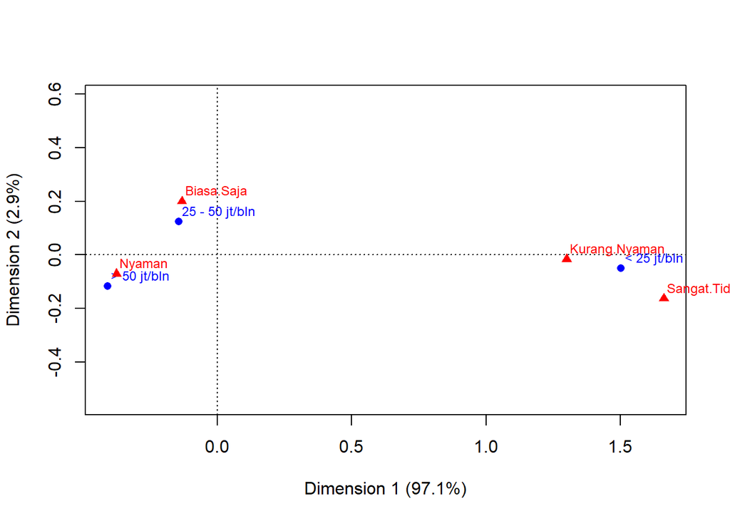

```r
plot(fit)
```

- Pekerja yang merasa Sangat tidak nyaman dan kurang nyaman dengan pekerjaannya cenderung yang memiliki pendapatan < 25juta.
- Pendapatan diantara 25 juta hingga 50 juta cenderung merasa biasa saja terhadap pekerjaannya.
- Pendapatan yang lebih dari 50 juta merasa Nyaman dengan pekerjaannya.

# Pertemuan 13 Analisis korelasi kanonik

## Langkah-Langkah

Analisis korelasi kanonik dilakukan dengan tahapan sebagai berikut:

1. Melakukan eksplorasi data dan uji asumsi analisis korelasi kanonik
2. Menentukan fungsi kanonik dan ukuran kesesuaiannya
3. Menginterpretasikan hasil analisis korelasi kanonik
4. Melakukan validasi hasil analisis korelasi kanonik

## Studi Kasus - 1

- Suatu survey terhadap 50 orang dilakukan untuk mengetahui apa faktor yang berhubungan dengan *sales performance*.
- Peubah yang di ukur adalah **Sales Performance (X)** yang terdiri atas *Sales Growth* (X1), *Sales Profitability* (X2), dan *New Account Sales* (X3) serta *Intelligence Test Score* (Y) yang terdiri atas *Creativity* (Y1), *Mechanical Reasoning* (Y2), *Abstract Reasoning* (Y3), dan *Mathematics* (Y4).
- Lakukan analisis dari data berikut menggunakan korelasi kanonik menggunakan R atau software lain yang sesuai.

```r
data_sales <- read.csv("https://online.stat.psu.edu/stat505/sites/stat505/files/lesson13/sales.csv", sep = ",")
library(knitr)
kable(head(data_sales))
```

| growth | profit | new | create | mech | abs | math |
| --- | --- | --- | --- | --- | --- | --- |
| 93.0 | 96.0 | 97.8 | 9 | 12 | 9 | 20 |
| 88.8 | 91.8 | 96.8 | 7 | 10 | 10 | 15 |
| 95.0 | 100.3 | 99.0 | 8 | 12 | 9 | 26 |
| 101.3 | 103.8 | 106.8 | 13 | 14 | 12 | 29 |
| 102.0 | 107.8 | 103.0 | 10 | 15 | 12 | 32 |
| 95.8 | 97.5 | 99.3 | 10 | 14 | 11 | 21 |

Pisahkan masing-masing peubah berdasarkan gugusnya.

```r
sales_X <- data_sales[,1:3]
sales_Y <- data_sales[,4:7]
```